# R Programming Midterm 201901 - Analysis

coop711

2019-04-22

## Excel 자료 읽어들이기

01반과 02반의 응답 코딩시트를 각각 읽어들이고 `rbind`를 이용하여 합친다.

```r
midterm_roll01 <- read.xlsx("../data/midterm1901_01.xlsx",
                          sheetIndex = 1,
                          startRow = 3,
                          endRow  = 41,
                          colIndex = c(4, 10:49),
                          colClasses = rep("character", 41),
                          encoding = "UTF-8",
                          header = FALSE,
                          stringsAsFactors = FALSE)
midterm_roll02 <- read.xlsx("../data/midterm1901_02.xlsx",
                          sheetIndex = 1,
                          startRow = 3,
                          endRow  = 41,
                          colIndex = c(4, 10:49),
                          colClasses = rep("character", 41),
                          encoding = "UTF-8",
                          header = FALSE,
                          stringsAsFactors = FALSE)
midterm_roll <- rbind(midterm_roll01, midterm_roll02)
names(midterm_roll) <- c("id", paste("Q", 1:40, sep = ""))
kable(head(midterm_roll[, 2:21]))
```

| Q1 | Q2 | Q3 | Q4 | Q5 | Q6 | Q7 | Q8 | Q9 | Q10 | Q11 | Q12 | Q13 | Q14 | Q15 | Q16 | Q17 | Q18 | Q19 | Q20 |
| --- | --- | --- | --- | --- | --- | --- | --- | --- | --- | --- | --- | --- | --- | --- | --- | --- | --- | --- | --- |
| 4 | 4 | 1 | 1 | 1 | 4 | 4 | 4 | 1 | 1 | 2 | 2 | 1 | 1 | 3 | 3 | 2 | 2 | 4 | 2 |
| 4 | 4 | 4 | 1 | 1 | 4 | 2 | 4 | 1 | 2 | 2 | 4 | 1 | 1 | 3 | 3 | 3 | 2 | 1 | 1 |
| 4 | 4 | 4 | 1 | 1 | 4 | 2 | 4 | 1 | 2 | 2 | 4 | 1 | 1 | 2 | 3 | 2 | 2 | 1 | 2 |
| 4 | 4 | 4 | 1 | 1 | 1 | 2 | 4 | 1 | 3 | 2 | 4 | 1 | 1 | 3 | 3 | 3 | 2 | 1 | 2 |
| 4 | 4 | 4 | 1 | 1 | 4 | 2 | 4 | 1 | 2 | 2 | 4 | 1 | 1 | 2 | 3 | 3 | 2 | 1 | 2 |
| 4 | 4 | 4 | 2 | 1 | 4 | 2 | 4 | 1 | 2 | 2 | 3 | 1 | 1 | 2 | 3 | 3 | 2 | 1 | 2 |

```r
kable(head(midterm_roll[, 22:41]))
```

| Q21 | Q22 | Q23 | Q24 | Q25 | Q26 | Q27 | Q28 | Q29 | Q30 | Q31 | Q32 | Q33 | Q34 | Q35 | Q36 | Q37 | Q38 | Q39 | Q40 |
| --- | --- | --- | --- | --- | --- | --- | --- | --- | --- | --- | --- | --- | --- | --- | --- | --- | --- | --- | --- |
| 1 | 3 | 1 | 3 | 1 | 3 | 2 | 1 | 2 | 1 | 4 | 4 | 1 | 2 | 2 | 2 | 1 | 1 | 3 | 4 |
| 2 | 3 | 3 | 3 | 4 | 3 | 2 | 1 | 4 | 1 | 1 | 4 | 1 | 2 | 2 | 2 | 4 | 2 | 3 | 4 |
| 1 | 3 | 1 | 3 | 4 | 3 | 2 | 2 | 4 | 1 | 1 | 4 | 1 | 2 | 3 | 2 | 1 | 2 | 3 | 2 |
| 1 | 3 | 1 | 3 | 1 | 3 | 2 | 4 | 1 | 1 | 1 | 4 | 1 | 2 | 2 | 1 | 3 | 1 | 3 | 2 |
| 1 | 3 | 1 | 3 | 1 | 3 | 4 | 2 | 3 | 1 | 4 | 4 | 1 | 2 | 2 | 2 | 3 | 1 | 3 | 2 |
| 1 | 3 | 1 | 3 | 1 | 3 | 2 | 4 | 2 | 1 | 1 | 4 | 1 | 2 | 2 | 2 | 3 | 2 | 3 | 4 |

```
## 'data.frame':    78 obs. of  41 variables:
##  $ id : chr  "20183202" "20162104" "20173208" "20183205" ...
##  $ Q1 : chr  "4" "4" "4" "4" ...
##  $ Q2 : chr  "4" "4" "4" "4" ...
##  $ Q3 : chr  "1" "4" "4" "4" ...
##  $ Q4 : chr  "1" "1" "1" "1" ...
##  $ Q5 : chr  "1" "1" "1" "1" ...
##  $ Q6 : chr  "4" "4" "4" "1" ...
##  $ Q7 : chr  "4" "2" "2" "2" ...
##  $ Q8 : chr  "4" "4" "4" "4" ...
##  $ Q9 : chr  "1" "1" "1" "1" ...
##  $ Q10: chr  "1" "2" "2" "3" ...
##  $ Q11: chr  "2" "2" "2" "2" ...
##  $ Q12: chr  "2" "4" "4" "4" ...
##  $ Q13: chr  "1" "1" "1" "1" ...
```

[output cut: 27 more lines]

| Q1 | Q2 | Q3 | Q4 | Q5 | Q6 | Q7 | Q8 | Q9 | Q10 | Q11 | Q12 | Q13 | Q14 | Q15 | Q16 | Q17 | Q18 | Q19 | Q20 |
| --- | --- | --- | --- | --- | --- | --- | --- | --- | --- | --- | --- | --- | --- | --- | --- | --- | --- | --- | --- |
| 4 | 4 | 1 | 1 | 1 | 4 | 4 | 4 | 1 | 1 | 2 | 2 | 1 | 1 | 3 | 3 | 2 | 2 | 4 | 2 |
| 4 | 4 | 4 | 1 | 1 | 4 | 2 | 4 | 1 | 2 | 2 | 4 | 1 | 1 | 3 | 3 | 3 | 2 | 1 | 1 |
| 4 | 4 | 4 | 1 | 1 | 4 | 2 | 4 | 1 | 2 | 2 | 4 | 1 | 1 | 2 | 3 | 2 | 2 | 1 | 2 |
| 4 | 4 | 4 | 1 | 1 | 1 | 2 | 4 | 1 | 3 | 2 | 4 | 1 | 1 | 3 | 3 | 3 | 2 | 1 | 2 |
| 4 | 4 | 4 | 1 | 1 | 4 | 2 | 4 | 1 | 2 | 2 | 4 | 1 | 1 | 2 | 3 | 3 | 2 | 1 | 2 |
| 4 | 4 | 4 | 2 | 1 | 4 | 2 | 4 | 1 | 2 | 2 | 3 | 1 | 1 | 2 | 3 | 3 | 2 | 1 | 2 |
| 4 | 4 | 3 | 1 | 1 | 4 | 2 | 4 | 1 | 2 | 2 | 4 | 1 | 1 | 2 | 3 | 3 | 2 | 3 | 2 |
| 4 | 4 | 3 | 1 | 1 | 4 | 3 | 4 | 1 | 2 | 4 | 4 | 3 | 1 | 2 | 3 | 1 | 2 | 3 | 2 |
| 4 | 4 | 3 | 1 | 1 | 4 | 2 | 4 | 1 | 2 | 2 | 4 | 1 | 1 | 2 | 3 | 1 | 2 | 3 | 2 |
| 4 | 4 | 1 | 1 | 1 | 4 | 4 | 4 | 1 | 1 | 2 | 2 | 1 | 1 | 2 | 3 | 1 | 2 | 3 | 2 |
| 4 | 4 | 3 | 1 | 1 | 4 | 2 | 4 | 1 | 2 | 2 | 4 | 1 | 1 | 2 | 3 | 3 | 2 | 4 | 2 |
| 4 | 4 | 2 | 1 | 1 | 4 | 2 | 4 | 1 | 2 | 2 | 4 | 1 | 1 | 2 | 3 | 3 | 2 | 2 | 2 |
| 4 | 4 | 3 | 1 | 1 | 4 | 4 | 4 | 1 | 2 | 2 | 4 | 1 | 1 | 2 | 3 | 3 | 2 | 1 | 2 |
| 4 | 4 | 1 | 2 | 1 | 4 | 3 | 4 | 1 | 3 | 2 | 4 | 1 | 1 | 3 | 3 | 3 | 2 | 1 | 2 |
| 4 | 4 | 4 | 1 | 1 | 4 | 2 | 4 | 1 | 2 | 2 | 4 | 1 | 1 | 2 | 3 | 3 | 3 | 3 | 2 |
| 4 | 4 | 3 | 1 | 1 | 4 | 2 | 4 | 1 | 2 | 4 | 4 | 1 | 1 | 2 | 3 | 3 | 2 | 1 | 2 |
| 4 | 4 | 4 | 1 | 1 | 4 | 2 | 4 | 1 | 1 | 2 | 4 | 1 | 1 | 2 | 3 | 1 | 2 | 3 | 2 |
| 4 | 4 | 3 | 1 | 1 | 4 | 2 | 4 | 1 | 2 | 2 | 4 | 1 | 1 | 3 | 3 | 3 | 2 | 3 | 2 |
| 4 | 4 | 4 | 1 | 1 | 4 | 2 | 4 | 1 | 1 | 2 | 4 | 1 | 1 | 2 | 3 | 2 | 2 | 3 | 2 |
| 4 | 4 | 4 | 1 | 1 | 4 | 2 | 4 | 1 | 1 | 2 | 4 | 1 | 1 | 2 | 3 | 3 | 2 | 1 | 2 |
| 4 | 4 | 3 | 1 | 1 | 4 | 2 | 4 | 1 | 2 | 2 | 4 | 1 | 1 | 2 | 3 | 3 | 2 | 1 | 2 |
| 4 | 4 | 4 | 1 | 1 | 4 | 2 | 4 | 1 | 2 | 2 | 4 | 1 | 1 | 2 | 3 | 4 | 2 | 1 | 2 |
| 4 | 4 | 4 | 1 | 1 | 4 | 3 | 4 | 1 | 2 | 4 | 4 | 1 | 1 | 2 | 3 | 3 | 2 | 3 | 2 |
| 4 | 4 | 3 | 1 | 1 | 4 | 2 | 4 | 1 | 4 | 2 | 4 | 1 | 1 | 2 | 3 | 4 | 2 | 1 | 2 |
| 4 | 3 | 3 | 1 | 1 | 4 | 2 | 4 | 1 | 2 | 2 | 3 | 1 | 1 | 4 | 3 | 3 | 2 | 4 | 1 |
| 4 | 4 | 3 | 1 | 1 | 4 | 2 | 4 | 1 | 2 | 2 | 4 | 1 | 1 | 2 | 3 | 1 | 2 | 4 | 2 |
| 4 | 4 | 3 | 1 | 4 | 4 | 2 | 4 | 1 | 1 | 2 | 4 | 1 | 1 | 2 | 3 | 2 | 2 | 1 | 2 |
| 4 | 4 | 4 | 1 | 1 | 4 | 2 | 4 | 1 | 2 | 2 | 4 | 1 | 1 | 2 | 3 | 3 | 2 | 1 | 2 |
| 4 | 4 | 3 | 1 | 1 | 4 | 4 | 4 | 2 | 1 | 2 | 4 | 1 | 1 | 3 | 3 | 2 | 2 | 1 | 2 |
| 4 | 4 | 3 | 1 | 1 | 4 | 2 | 4 | 1 | 1 | 2 | 4 | 1 | 1 | 2 | 3 | 2 | 2 | 1 | 2 |
| 4 | 4 | 4 | 1 | 1 | 4 | 2 | 4 | 1 | 2 | 2 | 4 | 1 | 1 | 2 | 3 | 3 | 2 | 1 | 2 |
| 4 | 4 | 4 | 1 | 1 | 1 | 3 | 4 | 1 | 1 | 2 | 4 | 1 | 1 | 3 | 3 | 3 | 2 | 4 | 2 |
| 4 | 4 | 3 | 1 | 1 | 4 | 2 | 4 | 1 | 1 | 2 | 4 | 1 | 1 | 2 | 3 | 3 | 2 | 1 | 2 |
| 4 | 3 | 3 | 1 | 1 | 4 | 2 | 4 | 1 | NA | 2 | 2 | 1 | 1 | 2 | 3 | 3 | 2 | 3 | 2 |
| 4 | 4 | 3 | 1 | 1 | 4 | 2 | 4 | 1 | 2 | 2 | 3 | 1 | 1 | 2 | 3 | 3 | 2 | 4 | 2 |
| 4 | 4 | 3 | 1 | 1 | 4 | 2 | 4 | 1 | 1 | 2 | 4 | 1 | 1 | 2 | 3 | 2 | 2 | 1 | 2 |
| 4 | 4 | 4 | 1 | 1 | 4 | 3 | 4 | 1 | 2 | 2 | 3 | 1 | 1 | 2 | 3 | 3 | 2 | 1 | 2 |
| 4 | 4 | 4 | 1 | 1 | 4 | 2 | 4 | 1 | 2 | 2 | 4 | 1 | 1 | 2 | 3 | 1 | 2 | 3 | 2 |
| 4 | 4 | 4 | 1 | 1 | 4 | 2 | 4 | 1 | 2 | 2 | 4 | 1 | 1 | 2 | 3 | 2 | 2 | 3 | 2 |
| 4 | 4 | 3 | 1 | 1 | 4 | 2 | 4 | 1 | 2 | 2 | 4 | 1 | 1 | 3 | 3 | 3 | 2 | 3 | 2 |
| 4 | 4 | 4 | 1 | 1 | 4 | 4 | 4 | 1 | 1 | 2 | 4 | 1 | 1 | 2 | 3 | 2 | 2 | 4 | 2 |
| 4 | 4 | 4 | 4 | 1 | 4 | 2 | 4 | 1 | 2 | 2 | 4 | 1 | 1 | 3 | 3 | 2 | 2 | 4 | 2 |
| 4 | 4 | 2 | 1 | 1 | 4 | 3 | 4 | 1 | 1 | 2 | 4 | 1 | 1 | 3 | 3 | 4 | 2 | 3 | 2 |
| 4 | 4 | 4 | 1 | 1 | 4 | 2 | 4 | 1 | 2 | 2 | 4 | 1 | 1 | 2 | 3 | 3 | 2 | 1 | 2 |
| 4 | 4 | 4 | 2 | 1 | 4 | 2 | 4 | 1 | 2 | 2 | 4 | 1 | 1 | 2 | 3 | 1 | 2 | 1 | 2 |
| 4 | 4 | 4 | 1 | 1 | 4 | 2 | 4 | 1 | 1 | 2 | 4 | 1 | 1 | 2 | 3 | 3 | 2 | 4 | 2 |
| 4 | 4 | 4 | 1 | 1 | 4 | 2 | 4 | 1 | 2 | 2 | 4 | 1 | 1 | 2 | 3 | 3 | 2 | 1 | 2 |
| 4 | 4 | 1 | 1 | 1 | 4 | 2 | 4 | 2 | 1 | 2 | 4 | 1 | 1 | 1 | 3 | 2 | 2 | 4 | 2 |
| 4 | 4 | 4 | 1 | 1 | 4 | 2 | 4 | 1 | 2 | 2 | 4 | 1 | 1 | 2 | 3 | 3 | 2 | 1 | 2 |
| 4 | 4 | 3 | 1 | 1 | 4 | 2 | 4 | 1 | 2 | 2 | 4 | 1 | 1 | 2 | 3 | 3 | 2 | 1 | 2 |
| 4 | 4 | 4 | 2 | 1 | 4 | 2 | 4 | 1 | 1 | 2 | 4 | 1 | 1 | 2 | 3 | 1 | 2 | 3 | 2 |
| 4 | 4 | 2 | 3 | 1 | 4 | 4 | 4 | 1 | 1 | 2 | 4 | 3 | 1 | 1 | 2 | 3 | 2 | 3 | 2 |
| 4 | 4 | 3 | 3 | 3 | 4 | 2 | 4 | 1 | 1 | 2 | 4 | 1 | 1 | 1 | 3 | 2 | 2 | 1 | 2 |
| 4 | 4 | 4 | 1 | 1 | 4 | 2 | 4 | 1 | 2 | 2 | 4 | 1 | 1 | 2 | 3 | 3 | 2 | 4 | 2 |
| 4 | 4 | 3 | 1 | 1 | 4 | 2 | 4 | 1 | 3 | 2 | 4 | 1 | 1 | 1 | 3 | 3 | 2 | 4 | 2 |
| 4 | 4 | 4 | 1 | 1 | 4 | 2 | 4 | 1 | 2 | 2 | 4 | 1 | 1 | 2 | 3 | 3 | 2 | 1 | 2 |
| 4 | 4 | 2 | 1 | 1 | 4 | 2 | 4 | 1 | 2 | 2 | 4 | 1 | 1 | 3 | 3 | 3 | 2 | 2 | 2 |
| 4 | 4 | 3 | 1 | 1 | 4 | 2 | 4 | 1 | 1 | 2 | 4 | 1 | 1 | 3 | 3 | 4 | 2 | 4 | 2 |
| 4 | 4 | 4 | 1 | 1 | 4 | 2 | 4 | 1 | 2 | 2 | 4 | 1 | 1 | 2 | 3 | 3 | 2 | 1 | 2 |
| 4 | 4 | 3 | 1 | 1 | 4 | 3 | 4 | 1 | 1 | 2 | 4 | 1 | 1 | 2 | 3 | 4 | 2 | 1 | 2 |
| 4 | 4 | 3 | 2 | 1 | 4 | 2 | 4 | 1 | 1 | 4 | 4 | 1 | 1 | 4 | 3 | 2 | 4 | 3 | 2 |
| 4 | 4 | 4 | 1 | 1 | 4 | 2 | 4 | 1 | 2 | 2 | 4 | 1 | 1 | 1 | 3 | 1 | 2 | 1 | 2 |
| 4 | 3 | 3 | 2 | 2 | 4 | 2 | 2 | 3 | 2 | 1 | 4 | 3 | 1 | 1 | 3 | 2 | 2 | 1 | 1 |
| 4 | 4 | 4 | 1 | 1 | 4 | 4 | 4 | 1 | 3 | 2 | 4 | 1 | 1 | 2 | 3 | 2 | 2 | 4 | 2 |
| 4 | 4 | 3 | 2 | 1 | 4 | 2 | 4 | 2 | 1 | 1 | 1 | 3 | 1 | 1 | 2 | 1 | 2 | 4 | 1 |
| 4 | 4 | 4 | 1 | 1 | 4 | 2 | 4 | 1 | 2 | 2 | 4 | 1 | 1 | 2 | 3 | 3 | 2 | 3 | 2 |
| 4 | 4 | 3 | 1 | 1 | 4 | 2 | 4 | 1 | 2 | 2 | 4 | 1 | 1 | 3 | 3 | 2 | 2 | 1 | 2 |
| 4 | 4 | 4 | 1 | 1 | 4 | 2 | 4 | 1 | 2 | 2 | 4 | 1 | 1 | 3 | 3 | 2 | 2 | 3 | 2 |
| 4 | 4 | 4 | 1 | 1 | 4 | 2 | 4 | 1 | 2 | 2 | 4 | 1 | 1 | 2 | 3 | 3 | 2 | 1 | 2 |
| 4 | 4 | 2 | 1 | 1 | 4 | 3 | 4 | 1 | 2 | 2 | 4 | 1 | 1 | 3 | 3 | 2 | 2 | 4 | 2 |
| 4 | 4 | 4 | 1 | 1 | 4 | 3 | 4 | 1 | 2 | 2 | 4 | 1 | 1 | 2 | 3 | 3 | 2 | 2 | 2 |
| 4 | 4 | 4 | 1 | 1 | 4 | 2 | 4 | 1 | 1 | 2 | 4 | 1 | 1 | 2 | 3 | 3 | 2 | 3 | 2 |
| 4 | 4 | 2 | 1 | 1 | 4 | 1 | 4 | 1 | 1 | 2 | 2 | 1 | 1 | 2 | 3 | 1 | 2 | 2 | 2 |
| 4 | 4 | 4 | 1 | 1 | 4 | 3 | 4 | 1 | 2 | 2 | 4 | 1 | 1 | 1 | 3 | 2 | 2 | 1 | 2 |
| 4 | 4 | 4 | 1 | 1 | 4 | 3 | 4 | 1 | 2 | 2 | 4 | 1 | 1 | 2 | 3 | 3 | 2 | 1 | 2 |
| 4 | 4 | 3 | 1 | 1 | 4 | 4 | 4 | 1 | 2 | 2 | 4 | 1 | 1 | 3 | 3 | 1 | 2 | 3 | 2 |
| 4 | 4 | 3 | 1 | 1 | 4 | 2 | 4 | 1 | 2 | 2 | 4 | 1 | 1 | 2 | 3 | 2 | 2 | 1 | 2 |
| 4 | 4 | 1 | 1 | 1 | 4 | 2 | 4 | 1 | 1 | 2 | 4 | 1 | 1 | 3 | 3 | 2 | 2 | 1 | 2 |

| Q21 | Q22 | Q23 | Q24 | Q25 | Q26 | Q27 | Q28 | Q29 | Q30 | Q31 | Q32 | Q33 | Q34 | Q35 | Q36 | Q37 | Q38 | Q39 | Q40 |
| --- | --- | --- | --- | --- | --- | --- | --- | --- | --- | --- | --- | --- | --- | --- | --- | --- | --- | --- | --- |
| 1 | 3 | 1 | 3 | 1 | 3 | 2 | 1 | 2 | 1 | 4 | 4 | 1 | 2 | 2 | 2 | 1 | 1 | 3 | 4 |
| 2 | 3 | 3 | 3 | 4 | 3 | 2 | 1 | 4 | 1 | 1 | 4 | 1 | 2 | 2 | 2 | 4 | 2 | 3 | 4 |
| 1 | 3 | 1 | 3 | 4 | 3 | 2 | 2 | 4 | 1 | 1 | 4 | 1 | 2 | 3 | 2 | 1 | 2 | 3 | 2 |
| 1 | 3 | 1 | 3 | 1 | 3 | 2 | 4 | 1 | 1 | 1 | 4 | 1 | 2 | 2 | 1 | 3 | 1 | 3 | 2 |
| 1 | 3 | 1 | 3 | 1 | 3 | 4 | 2 | 3 | 1 | 4 | 4 | 1 | 2 | 2 | 2 | 3 | 1 | 3 | 2 |
| 1 | 3 | 1 | 3 | 1 | 3 | 2 | 4 | 2 | 1 | 1 | 4 | 1 | 2 | 2 | 2 | 3 | 2 | 3 | 4 |
| 1 | 1 | 1 | 3 | 1 | 4 | 2 | 2 | 1 | 1 | 4 | 4 | 1 | 2 | 2 | 2 | 3 | 1 | 3 | 2 |
| 1 | 3 | 2 | 4 | 1 | 3 | 2 | 2 | 1 | 2 | 4 | 4 | 3 | 2 | 2 | 2 | 3 | 2 | 2 | 4 |
| 1 | 3 | 1 | 3 | 3 | 3 | 2 | 4 | 1 | 1 | 4 | 4 | 1 | 1 | 2 | 2 | 3 | 3 | 3 | 4 |
| 1 | 4 | 1 | 1 | 2 | 3 | 2 | 4 | 1 | 1 | 1 | 4 | 1 | 1 | 2 | 2 | 3 | 2 | 3 | 4 |
| 1 | 3 | 1 | 3 | 4 | 3 | 2 | 2 | 1 | 1 | 4 | 4 | 1 | 2 | 2 | 2 | 3 | 1 | 3 | 4 |
| 1 | 3 | 1 | 3 | 2 | 3 | 2 | 1 | 2 | 1 | 3 | 4 | 1 | 2 | 2 | 2 | 2 | 3 | 3 | 2 |
| 1 | 3 | 1 | 3 | 1 | 3 | 2 | 1 | 1 | 1 | 1 | 4 | 1 | 2 | 2 | 2 | 3 | 1 | 3 | 2 |
| 1 | 3 | 1 | 3 | 1 | 3 | 4 | 3 | 3 | 1 | 4 | 4 | 1 | 2 | 2 | 2 | 4 | 1 | 2 | 4 |
| 1 | 3 | 1 | 3 | 1 | 3 | 2 | 2 | 1 | 1 | 4 | 4 | 1 | 2 | 2 | 2 | 1 | 2 | 3 | 2 |
| 1 | 3 | 1 | 3 | 1 | 3 | 2 | 3 | 1 | 1 | 4 | 4 | 1 | 2 | 2 | 1 | 3 | 1 | 3 | 4 |
| 1 | 3 | 1 | 3 | 4 | 3 | 2 | 3 | 2 | 1 | 4 | 4 | 1 | 2 | 2 | 2 | 2 | 1 | 1 | 2 |
| 1 | 3 | 1 | 3 | 1 | 3 | 2 | 1 | 1 | 1 | 4 | 4 | 1 | 2 | 2 | 2 | 1 | 1 | 3 | 2 |
| 1 | 3 | 1 | 3 | 4 | 3 | 2 | 2 | 2 | 1 | 4 | 4 | 1 | 2 | 2 | 2 | 1 | 2 | 1 | 3 |
| 1 | 3 | 1 | 3 | 1 | 3 | 2 | 2 | 1 | 1 | 4 | 4 | 1 | 2 | 2 | 2 | 1 | 1 | 3 | 2 |
| 1 | 4 | 1 | 4 | 1 | 4 | 2 | 4 | 1 | 1 | 4 | 4 | 1 | 2 | 2 | 2 | 1 | 2 | 3 | 4 |
| 1 | 2 | 1 | 3 | 1 | 1 | 1 | 2 | 2 | 1 | 4 | 4 | 1 | 2 | 2 | 2 | 3 | 1 | 3 | 2 |
| 1 | 3 | 1 | 3 | 4 | 3 | 2 | 4 | 2 | 1 | 1 | 4 | 1 | 2 | 2 | 2 | 3 | 1 | 3 | 4 |
| 1 | 3 | 1 | 3 | 1 | 3 | 2 | 1 | 3 | 1 | 4 | 4 | 1 | 2 | 2 | 2 | 2 | 4 | 3 | 4 |
| 1 | 3 | 4 | 1 | 1 | 3 | 2 | 4 | 1 | 1 | 3 | 2 | 2 | 1 | 2 | 2 | 4 | 3 | 2 | 3 |
| 1 | 3 | 1 | 3 | 1 | 3 | 2 | 2 | 2 | 1 | 1 | 4 | 1 | 2 | 2 | 2 | 3 | 2 | 3 | 2 |
| 1 | 3 | 1 | 3 | 1 | 3 | 2 | 2 | 2 | 1 | 4 | 4 | 1 | 2 | 2 | 2 | 1 | 3 | 4 | 2 |
| 1 | 4 | 1 | 3 | 1 | 3 | 2 | 2 | 1 | 1 | 4 | 4 | 1 | 2 | 2 | 2 | 1 | 2 | 3 | 2 |
| 1 | 3 | 1 | 3 | 1 | 3 | 4 | 1 | 2 | 1 | 4 | 4 | 1 | 1 | 2 | 2 | 3 | 2 | 3 | 2 |
| 1 | 3 | 1 | 3 | 1 | 3 | 2 | 1 | 1 | 1 | 1 | 4 | 1 | 2 | 2 | 2 | 1 | 2 | 3 | 2 |
| 1 | 2 | 1 | 3 | 4 | 3 | 2 | 1 | 2 | 1 | 4 | 4 | 1 | 2 | 2 | 2 | 3 | 1 | 3 | 2 |
| 1 | 3 | 1 | 3 | 4 | 3 | 2 | 1 | 1 | 1 | 4 | 4 | 1 | 2 | 2 | 2 | 1 | 3 | 3 | 2 |
| 1 | 4 | 4 | 3 | 4 | 3 | 2 | 1 | 2 | 1 | 4 | 4 | 1 | 2 | 2 | 4 | 2 | 1 | 2 | 2 |
| 1 | 3 | 1 | 3 | 1 | 3 | 4 | 1 | 1 | 4 | 4 | 2 | 3 | 2 | 2 | 2 | 4 | 3 | 4 | 4 |
| 1 | 3 | 1 | 3 | 1 | 3 | 2 | 2 | 1 | 1 | 4 | 4 | 1 | 2 | 2 | 2 | 1 | 1 | 3 | 2 |
| 2 | 4 | 4 | 3 | 1 | 4 | 2 | 4 | 1 | 1 | 4 | 4 | 4 | 1 | 2 | 2 | 1 | 1 | 4 | 2 |
| 1 | 4 | 1 | 3 | 1 | 3 | 2 | 4 | 1 | 1 | 4 | 4 | 1 | 2 | 2 | 2 | 1 | 2 | 3 | 2 |
| 1 | 3 | 1 | 3 | 1 | 3 | 2 | 1 | 2 | 1 | 1 | 4 | 1 | 2 | 2 | 2 | 4 | 1 | 3 | 2 |
| 1 | 3 | 1 | 3 | 1 | 3 | 2 | 2 | 1 | 1 | 1 | 4 | 1 | 2 | 2 | 2 | 3 | 1 | 3 | 2 |
| 1 | 3 | 1 | 3 | 1 | 3 | 2 | 1 | 1 | 1 | 1 | 4 | 1 | 2 | 2 | 2 | 1 | 2 | 3 | 2 |
| 1 | 4 | 1 | 3 | 4 | 3 | 2 | 1 | 2 | 1 | 4 | 4 | 1 | 4 | 2 | 2 | 2 | 4 | 4 | 3 |
| 1 | 3 | 2 | 3 | 3 | 3 | 2 | 2 | 1 | 1 | 1 | 4 | 1 | 4 | 2 | 4 | 2 | 3 | 3 | 2 |
| 1 | 3 | 1 | 3 | 1 | 3 | 2 | 4 | 2 | 1 | 1 | 4 | 1 | 2 | 2 | 2 | 1 | 3 | 3 | 2 |
| 1 | 4 | 1 | 3 | 1 | 3 | 2 | 2 | 1 | 1 | 1 | 4 | 1 | 2 | 2 | 2 | 1 | 2 | 3 | 2 |
| 1 | 3 | 1 | 3 | 1 | 3 | 2 | 4 | 1 | 1 | 4 | 4 | 1 | 2 | 2 | 2 | 1 | 2 | 3 | 2 |
| 1 | 3 | 1 | 3 | 1 | 3 | 2 | 2 | 2 | 1 | 1 | 4 | 1 | 1 | 2 | 2 | 3 | 1 | 3 | 2 |
| 1 | 3 | 1 | 3 | 1 | 3 | 2 | 2 | 1 | 1 | 1 | 4 | 1 | 2 | 2 | 2 | 1 | 1 | 3 | 2 |
| 1 | 3 | 1 | 3 | 1 | 3 | 2 | 4 | 2 | 1 | 1 | 4 | 1 | 2 | 2 | 3 | 2 | 3 | 1 | 3 |
| 1 | 3 | 1 | 3 | 1 | 3 | 2 | 4 | 1 | 1 | 1 | 4 | 1 | 2 | 2 | 1 | 3 | 2 | 3 | 4 |
| 1 | 3 | 1 | 3 | 1 | 3 | 2 | 1 | 1 | 1 | 4 | 4 | 1 | 2 | 2 | 2 | 3 | 1 | 3 | 2 |
| 1 | 2 | 1 | 3 | 2 | 3 | 2 | 4 | 2 | 1 | 1 | 4 | 1 | 2 | 2 | 2 | 4 | 2 | 2 | 2 |
| 1 | 3 | 1 | 3 | 2 | 3 | 2 | 3 | 2 | 2 | 4 | 4 | 3 | 2 | 2 | 2 | 1 | 2 | 1 | 4 |
| 1 | 4 | 4 | 3 | 2 | 3 | 2 | 4 | 2 | 1 | 4 | 4 | 3 | 2 | 2 | 3 | 1 | 3 | 4 | 3 |
| 1 | 3 | 1 | 3 | 2 | 3 | 2 | 4 | 2 | 1 | 4 | 4 | 1 | 4 | 2 | 2 | 2 | 1 | 1 | 2 |
| 1 | 3 | 2 | 3 | 1 | 3 | 2 | 2 | 2 | 1 | 4 | 4 | 1 | 1 | 2 | 1 | 3 | 1 | 3 | 2 |
| 1 | 3 | 1 | 3 | 1 | 3 | 2 | 4 | 1 | 1 | 1 | 4 | 1 | 2 | 2 | 2 | 3 | 4 | 3 | 4 |
| 1 | 2 | 1 | 3 | 1 | 3 | 2 | 4 | 1 | 1 | 4 | 4 | 1 | 2 | 2 | 2 | 1 | 1 | 2 | 4 |
| 1 | 3 | 1 | 3 | 3 | 3 | 2 | 4 | 1 | 1 | 4 | 4 | 1 | 2 | 2 | 2 | 1 | 1 | 1 | 2 |
| 1 | 3 | 1 | 3 | 1 | 3 | 2 | 2 | 1 | 1 | 1 | 4 | 1 | 2 | 2 | 2 | 1 | 2 | 3 | 4 |
| 1 | 2 | 1 | 3 | 1 | 3 | 2 | 4 | 2 | 1 | 4 | 4 | 1 | 2 | 2 | 2 | 2 | 1 | 3 | 2 |
| 1 | 4 | 1 | 4 | 1 | 3 | 2 | 2 | 2 | 1 | 4 | 4 | 1 | 2 | 2 | 2 | 3 | 2 | 3 | 2 |
| 1 | 4 | 1 | 3 | 1 | 3 | 4 | 1 | 2 | 1 | 4 | 4 | 1 | 2 | 2 | 1 | 1 | 2 | 4 | 4 |
| 1 | 3 | 4 | 2 | 2 | 2 | 2 | 3 | 3 | 3 | 2 | 4 | 3 | 3 | 3 | 2 | 2 | 2 | 4 | 4 |
| 1 | 3 | 1 | 1 | 3 | 3 | 2 | 4 | 2 | 1 | 4 | 4 | 1 | 1 | 2 | 2 | 4 | 1 | 3 | 2 |
| 2 | 3 | 1 | 1 | 4 | 1 | 3 | 4 | 3 | 2 | 4 | 2 | 1 | 1 | 2 | 3 | 4 | 3 | 4 | 3 |
| 1 | 3 | 1 | 3 | 1 | 3 | 2 | 4 | 1 | 1 | 1 | 4 | 1 | 2 | 2 | 2 | 3 | 2 | 3 | 2 |
| 1 | 3 | 3 | 3 | 1 | 3 | 2 | 2 | 1 | 1 | 1 | 4 | 1 | 2 | 2 | 2 | 3 | 2 | 3 | 2 |
| 1 | 4 | 1 | 3 | 2 | 2 | 2 | 2 | 1 | 1 | 4 | 4 | 1 | 2 | 2 | 2 | 4 | 1 | 3 | 2 |
| 1 | 3 | 1 | 3 | 4 | 3 | 2 | 1 | 1 | 1 | 1 | 4 | 1 | 2 | 1 | 2 | 1 | 2 | 3 | 2 |
| 1 | 3 | 1 | 3 | 4 | 3 | 2 | 4 | 2 | 1 | 4 | 4 | 1 | 2 | 2 | 2 | 2 | 1 | 3 | 2 |
| 1 | 3 | 1 | 3 | 1 | 3 | 2 | 2 | 4 | 1 | 1 | 4 | 1 | 2 | 2 | 2 | 2 | 2 | 3 | 2 |
| 1 | 3 | 1 | 3 | 4 | 3 | 2 | 1 | 2 | 1 | 4 | 4 | 1 | 1 | 2 | 1 | 4 | 2 | 2 | 4 |
| 1 | 3 | 1 | 3 | 1 | 1 | 2 | 1 | 1 | 1 | 4 | 4 | 1 | 2 | 2 | 2 | 3 | 1 | 3 | 4 |
| 1 | 3 | 1 | 3 | 1 | 3 | 2 | 3 | 3 | 1 | 4 | 4 | 1 | 2 | 2 | 2 | 4 | 1 | 4 | 2 |
| 1 | 3 | 1 | 3 | 1 | 3 | 4 | 4 | 2 | 1 | 4 | 4 | 1 | 2 | 2 | 2 | 1 | 2 | 3 | 4 |
| 1 | 3 | 1 | 3 | 1 | 3 | 4 | 2 | 1 | 1 | 4 | 4 | 1 | 1 | 2 | 2 | 3 | 1 | 2 | 2 |
| 1 | 3 | 1 | 3 | 1 | 3 | 4 | 4 | 1 | 1 | 1 | 4 | 1 | 2 | 2 | 1 | 1 | 1 | 4 | 4 |
| 1 | 4 | 1 | 3 | 2 | 3 | 2 | 4 | 1 | 1 | 3 | 4 | 1 | 1 | 2 | 2 | 2 | 1 | 3 | 4 |

# `factor` 변환

```r
midterm <- lapply(midterm, FUN = factor, levels = 1:4,
                  labels = c("가", "나", "다", "라"))
str(midterm)
```

```
## List of 40
##  $ Q1 : Factor w/ 4 levels "가","나","다",..: 4 4 4 4 4 4 4 4 4 4 ...
##  $ Q2 : Factor w/ 4 levels "가","나","다",..: 4 4 4 4 4 4 4 4 4 4 ...
##  $ Q3 : Factor w/ 4 levels "가","나","다",..: 1 4 4 4 4 4 3 3 3 1 ...
##  $ Q4 : Factor w/ 4 levels "가","나","다",..: 1 1 1 1 1 2 1 1 1 1 ...
##  $ Q5 : Factor w/ 4 levels "가","나","다",..: 1 1 1 1 1 1 1 1 1 1 ...
##  $ Q6 : Factor w/ 4 levels "가","나","다",..: 4 4 4 1 4 4 4 4 4 4 ...
##  $ Q7 : Factor w/ 4 levels "가","나","다",..: 4 2 2 2 2 2 2 3 2 4 ...
##  $ Q8 : Factor w/ 4 levels "가","나","다",..: 4 4 4 4 4 4 4 4 4 4 ...
##  $ Q9 : Factor w/ 4 levels "가","나","다",..: 1 1 1 1 1 1 1 1 1 1 ...
##  $ Q10: Factor w/ 4 levels "가","나","다",..: 1 2 2 3 2 2 2 2 2 1 ...
##  $ Q11: Factor w/ 4 levels "가","나","다",..: 2 2 2 2 2 2 2 4 2 2 ...
##  $ Q12: Factor w/ 4 levels "가","나","다",..: 2 4 4 4 4 3 4 4 4 2 ...
##  $ Q13: Factor w/ 4 levels "가","나","다",..: 1 1 1 1 1 1 1 3 1 1 ...
##  $ Q14: Factor w/ 4 levels "가","나","다",..: 1 1 1 1 1 1 1 1 1 1 ...
```

[output cut: 26 more lines]

```r
midterm <- data.frame(midterm, row.names = NULL)
str(midterm)
```

```
## 'data.frame':    78 obs. of  40 variables:
##  $ Q1 : Factor w/ 4 levels "가","나","다",..: 4 4 4 4 4 4 4 4 4 4 ...
##  $ Q2 : Factor w/ 4 levels "가","나","다",..: 4 4 4 4 4 4 4 4 4 4 ...
##  $ Q3 : Factor w/ 4 levels "가","나","다",..: 1 4 4 4 4 4 3 3 3 1 ...
##  $ Q4 : Factor w/ 4 levels "가","나","다",..: 1 1 1 1 1 2 1 1 1 1 ...
##  $ Q5 : Factor w/ 4 levels "가","나","다",..: 1 1 1 1 1 1 1 1 1 1 ...
##  $ Q6 : Factor w/ 4 levels "가","나","다",..: 4 4 4 1 4 4 4 4 4 4 ...
##  $ Q7 : Factor w/ 4 levels "가","나","다",..: 4 2 2 2 2 2 2 3 2 4 ...
##  $ Q8 : Factor w/ 4 levels "가","나","다",..: 4 4 4 4 4 4 4 4 4 4 ...
##  $ Q9 : Factor w/ 4 levels "가","나","다",..: 1 1 1 1 1 1 1 1 1 1 ...
##  $ Q10: Factor w/ 4 levels "가","나","다",..: 1 2 2 3 2 2 2 2 2 1 ...
##  $ Q11: Factor w/ 4 levels "가","나","다",..: 2 2 2 2 2 2 2 4 2 2 ...
##  $ Q12: Factor w/ 4 levels "가","나","다",..: 2 4 4 4 4 3 4 4 4 2 ...
##  $ Q13: Factor w/ 4 levels "가","나","다",..: 1 1 1 1 1 1 1 3 1 1 ...
##  $ Q14: Factor w/ 4 levels "가","나","다",..: 1 1 1 1 1 1 1 1 1 1 ...
```

[output cut: 26 more lines]

# 답안 분포

```r
kable(midterm[1:20])
```

| Q1 | Q2 | Q3 | Q4 | Q5 | Q6 | Q7 | Q8 | Q9 | Q10 | Q11 | Q12 | Q13 | Q14 | Q15 | Q16 | Q17 | Q18 | Q19 | Q20 |
| --- | --- | --- | --- | --- | --- | --- | --- | --- | --- | --- | --- | --- | --- | --- | --- | --- | --- | --- | --- |
| 라 | 라 | 가 | 가 | 가 | 라 | 라 | 라 | 가 | 가 | 나 | 나 | 가 | 가 | 다 | 다 | 나 | 나 | 라 | 나 |
| 라 | 라 | 라 | 가 | 가 | 라 | 나 | 라 | 가 | 나 | 나 | 라 | 가 | 가 | 다 | 다 | 다 | 나 | 가 | 가 |
| 라 | 라 | 라 | 가 | 가 | 라 | 나 | 라 | 가 | 나 | 나 | 라 | 가 | 가 | 나 | 다 | 나 | 나 | 가 | 나 |
| 라 | 라 | 라 | 가 | 가 | 가 | 나 | 라 | 가 | 다 | 나 | 라 | 가 | 가 | 다 | 다 | 다 | 나 | 가 | 나 |
| 라 | 라 | 라 | 가 | 가 | 라 | 나 | 라 | 가 | 나 | 나 | 라 | 가 | 가 | 나 | 다 | 다 | 나 | 가 | 나 |
| 라 | 라 | 라 | 나 | 가 | 라 | 나 | 라 | 가 | 나 | 나 | 다 | 가 | 가 | 나 | 다 | 다 | 나 | 가 | 나 |
| 라 | 라 | 다 | 가 | 가 | 라 | 나 | 라 | 가 | 나 | 나 | 라 | 가 | 가 | 나 | 다 | 다 | 나 | 다 | 나 |
| 라 | 라 | 다 | 가 | 가 | 라 | 다 | 라 | 가 | 나 | 라 | 라 | 다 | 가 | 나 | 다 | 가 | 나 | 다 | 나 |
| 라 | 라 | 다 | 가 | 가 | 라 | 나 | 라 | 가 | 나 | 나 | 라 | 가 | 가 | 나 | 다 | 가 | 나 | 다 | 나 |
| 라 | 라 | 가 | 가 | 가 | 라 | 라 | 라 | 가 | 가 | 나 | 나 | 가 | 가 | 나 | 다 | 가 | 나 | 다 | 나 |
| 라 | 라 | 다 | 가 | 가 | 라 | 나 | 라 | 가 | 나 | 나 | 라 | 가 | 가 | 나 | 다 | 다 | 나 | 라 | 나 |
| 라 | 라 | 나 | 가 | 가 | 라 | 나 | 라 | 가 | 나 | 나 | 라 | 가 | 가 | 나 | 다 | 다 | 나 | 나 | 나 |
| 라 | 라 | 다 | 가 | 가 | 라 | 라 | 라 | 가 | 나 | 나 | 라 | 가 | 가 | 나 | 다 | 다 | 나 | 가 | 나 |
| 라 | 라 | 가 | 나 | 가 | 라 | 다 | 라 | 가 | 다 | 나 | 라 | 가 | 가 | 다 | 다 | 다 | 나 | 가 | 나 |
| 라 | 라 | 라 | 가 | 가 | 라 | 나 | 라 | 가 | 나 | 나 | 라 | 가 | 가 | 나 | 다 | 다 | 다 | 다 | 나 |
| 라 | 라 | 다 | 가 | 가 | 라 | 나 | 라 | 가 | 나 | 라 | 라 | 가 | 가 | 나 | 다 | 다 | 나 | 가 | 나 |
| 라 | 라 | 라 | 가 | 가 | 라 | 나 | 라 | 가 | 가 | 나 | 라 | 가 | 가 | 나 | 다 | 가 | 나 | 다 | 나 |
| 라 | 라 | 다 | 가 | 가 | 라 | 나 | 라 | 가 | 나 | 나 | 라 | 가 | 가 | 다 | 다 | 다 | 나 | 다 | 나 |
| 라 | 라 | 라 | 가 | 가 | 라 | 나 | 라 | 가 | 가 | 나 | 라 | 가 | 가 | 나 | 다 | 나 | 나 | 다 | 나 |
| 라 | 라 | 라 | 가 | 가 | 라 | 나 | 라 | 가 | 가 | 나 | 라 | 가 | 가 | 나 | 다 | 다 | 나 | 가 | 나 |
| 라 | 라 | 다 | 가 | 가 | 라 | 나 | 라 | 가 | 나 | 나 | 라 | 가 | 가 | 나 | 다 | 다 | 나 | 가 | 나 |
| 라 | 라 | 라 | 가 | 가 | 라 | 나 | 라 | 가 | 나 | 나 | 라 | 가 | 가 | 나 | 다 | 라 | 나 | 가 | 나 |
| 라 | 라 | 라 | 가 | 가 | 라 | 다 | 라 | 가 | 나 | 라 | 라 | 가 | 가 | 나 | 다 | 다 | 나 | 다 | 나 |
| 라 | 라 | 다 | 가 | 가 | 라 | 나 | 라 | 가 | 라 | 나 | 라 | 가 | 가 | 나 | 다 | 라 | 나 | 가 | 나 |
| 라 | 다 | 다 | 가 | 가 | 라 | 나 | 라 | 가 | 나 | 나 | 다 | 가 | 가 | 라 | 다 | 다 | 나 | 라 | 가 |
| 라 | 라 | 다 | 가 | 가 | 라 | 나 | 라 | 가 | 나 | 나 | 라 | 가 | 가 | 나 | 다 | 가 | 나 | 라 | 나 |
| 라 | 라 | 다 | 가 | 라 | 라 | 나 | 라 | 가 | 가 | 나 | 라 | 가 | 가 | 나 | 다 | 나 | 나 | 가 | 나 |
| 라 | 라 | 라 | 가 | 가 | 라 | 나 | 라 | 가 | 나 | 나 | 라 | 가 | 가 | 나 | 다 | 다 | 나 | 가 | 나 |
| 라 | 라 | 다 | 가 | 가 | 라 | 라 | 라 | 나 | 가 | 나 | 라 | 가 | 가 | 다 | 다 | 나 | 나 | 가 | 나 |
| 라 | 라 | 다 | 가 | 가 | 라 | 나 | 라 | 가 | 가 | 나 | 라 | 가 | 가 | 나 | 다 | 나 | 나 | 가 | 나 |
| 라 | 라 | 라 | 가 | 가 | 라 | 나 | 라 | 가 | 나 | 나 | 라 | 가 | 가 | 나 | 다 | 다 | 나 | 가 | 나 |
| 라 | 라 | 라 | 가 | 가 | 가 | 다 | 라 | 가 | 가 | 나 | 라 | 가 | 가 | 다 | 다 | 다 | 나 | 라 | 나 |
| 라 | 라 | 다 | 가 | 가 | 라 | 나 | 라 | 가 | 가 | 나 | 라 | 가 | 가 | 나 | 다 | 다 | 나 | 가 | 나 |
| 라 | 다 | 다 | 가 | 가 | 라 | 나 | 라 | 가 | NA | 나 | 나 | 가 | 가 | 나 | 다 | 다 | 나 | 다 | 나 |
| 라 | 라 | 다 | 가 | 가 | 라 | 나 | 라 | 가 | 나 | 나 | 다 | 가 | 가 | 나 | 다 | 다 | 나 | 라 | 나 |
| 라 | 라 | 다 | 가 | 가 | 라 | 나 | 라 | 가 | 가 | 나 | 라 | 가 | 가 | 나 | 다 | 나 | 나 | 가 | 나 |
| 라 | 라 | 라 | 가 | 가 | 라 | 다 | 라 | 가 | 나 | 나 | 다 | 가 | 가 | 나 | 다 | 다 | 나 | 가 | 나 |
| 라 | 라 | 라 | 가 | 가 | 라 | 나 | 라 | 가 | 나 | 나 | 라 | 가 | 가 | 나 | 다 | 가 | 나 | 다 | 나 |
| 라 | 라 | 라 | 가 | 가 | 라 | 나 | 라 | 가 | 나 | 나 | 라 | 가 | 가 | 나 | 다 | 나 | 나 | 다 | 나 |
| 라 | 라 | 다 | 가 | 가 | 라 | 나 | 라 | 가 | 나 | 나 | 라 | 가 | 가 | 다 | 다 | 다 | 나 | 다 | 나 |
| 라 | 라 | 라 | 가 | 가 | 라 | 라 | 라 | 가 | 가 | 나 | 라 | 가 | 가 | 나 | 다 | 나 | 나 | 라 | 나 |
| 라 | 라 | 라 | 라 | 가 | 라 | 나 | 라 | 가 | 나 | 나 | 라 | 가 | 가 | 다 | 다 | 나 | 나 | 라 | 나 |
| 라 | 라 | 나 | 가 | 가 | 라 | 다 | 라 | 가 | 가 | 나 | 라 | 가 | 가 | 다 | 다 | 라 | 나 | 다 | 나 |
| 라 | 라 | 라 | 가 | 가 | 라 | 나 | 라 | 가 | 나 | 나 | 라 | 가 | 가 | 나 | 다 | 다 | 나 | 가 | 나 |
| 라 | 라 | 라 | 나 | 가 | 라 | 나 | 라 | 가 | 나 | 나 | 라 | 가 | 가 | 나 | 다 | 가 | 나 | 가 | 나 |
| 라 | 라 | 라 | 가 | 가 | 라 | 나 | 라 | 가 | 가 | 나 | 라 | 가 | 가 | 나 | 다 | 다 | 나 | 라 | 나 |
| 라 | 라 | 라 | 가 | 가 | 라 | 나 | 라 | 가 | 나 | 나 | 라 | 가 | 가 | 나 | 다 | 다 | 나 | 가 | 나 |
| 라 | 라 | 가 | 가 | 가 | 라 | 나 | 라 | 나 | 가 | 나 | 라 | 가 | 가 | 가 | 다 | 나 | 나 | 라 | 나 |
| 라 | 라 | 라 | 가 | 가 | 라 | 나 | 라 | 가 | 나 | 나 | 라 | 가 | 가 | 나 | 다 | 다 | 나 | 가 | 나 |
| 라 | 라 | 다 | 가 | 가 | 라 | 나 | 라 | 가 | 나 | 나 | 라 | 가 | 가 | 나 | 다 | 다 | 나 | 가 | 나 |
| 라 | 라 | 라 | 나 | 가 | 라 | 나 | 라 | 가 | 가 | 나 | 라 | 가 | 가 | 나 | 다 | 가 | 나 | 다 | 나 |
| 라 | 라 | 나 | 다 | 가 | 라 | 라 | 라 | 가 | 가 | 나 | 라 | 다 | 가 | 가 | 나 | 다 | 나 | 다 | 나 |
| 라 | 라 | 다 | 다 | 다 | 라 | 나 | 라 | 가 | 가 | 나 | 라 | 가 | 가 | 가 | 다 | 나 | 나 | 가 | 나 |
| 라 | 라 | 라 | 가 | 가 | 라 | 나 | 라 | 가 | 나 | 나 | 라 | 가 | 가 | 나 | 다 | 다 | 나 | 라 | 나 |
| 라 | 라 | 다 | 가 | 가 | 라 | 나 | 라 | 가 | 다 | 나 | 라 | 가 | 가 | 가 | 다 | 다 | 나 | 라 | 나 |
| 라 | 라 | 라 | 가 | 가 | 라 | 나 | 라 | 가 | 나 | 나 | 라 | 가 | 가 | 나 | 다 | 다 | 나 | 가 | 나 |
| 라 | 라 | 나 | 가 | 가 | 라 | 나 | 라 | 가 | 나 | 나 | 라 | 가 | 가 | 다 | 다 | 다 | 나 | 나 | 나 |
| 라 | 라 | 다 | 가 | 가 | 라 | 나 | 라 | 가 | 가 | 나 | 라 | 가 | 가 | 다 | 다 | 라 | 나 | 라 | 나 |
| 라 | 라 | 라 | 가 | 가 | 라 | 나 | 라 | 가 | 나 | 나 | 라 | 가 | 가 | 나 | 다 | 다 | 나 | 가 | 나 |
| 라 | 라 | 다 | 가 | 가 | 라 | 다 | 라 | 가 | 가 | 나 | 라 | 가 | 가 | 나 | 다 | 라 | 나 | 가 | 나 |
| 라 | 라 | 다 | 나 | 가 | 라 | 나 | 라 | 가 | 가 | 라 | 라 | 가 | 가 | 라 | 다 | 나 | 라 | 다 | 나 |
| 라 | 라 | 라 | 가 | 가 | 라 | 나 | 라 | 가 | 나 | 나 | 라 | 가 | 가 | 가 | 다 | 가 | 나 | 가 | 나 |
| 라 | 다 | 다 | 나 | 나 | 라 | 나 | 나 | 다 | 나 | 가 | 라 | 다 | 가 | 가 | 다 | 나 | 나 | 가 | 가 |
| 라 | 라 | 라 | 가 | 가 | 라 | 라 | 라 | 가 | 다 | 나 | 라 | 가 | 가 | 나 | 다 | 나 | 나 | 라 | 나 |
| 라 | 라 | 다 | 나 | 가 | 라 | 나 | 라 | 나 | 가 | 가 | 가 | 다 | 가 | 가 | 나 | 가 | 나 | 라 | 가 |
| 라 | 라 | 라 | 가 | 가 | 라 | 나 | 라 | 가 | 나 | 나 | 라 | 가 | 가 | 나 | 다 | 다 | 나 | 다 | 나 |
| 라 | 라 | 다 | 가 | 가 | 라 | 나 | 라 | 가 | 나 | 나 | 라 | 가 | 가 | 다 | 다 | 나 | 나 | 가 | 나 |
| 라 | 라 | 라 | 가 | 가 | 라 | 나 | 라 | 가 | 나 | 나 | 라 | 가 | 가 | 다 | 다 | 나 | 나 | 다 | 나 |
| 라 | 라 | 라 | 가 | 가 | 라 | 나 | 라 | 가 | 나 | 나 | 라 | 가 | 가 | 나 | 다 | 다 | 나 | 가 | 나 |
| 라 | 라 | 나 | 가 | 가 | 라 | 다 | 라 | 가 | 나 | 나 | 라 | 가 | 가 | 다 | 다 | 나 | 나 | 라 | 나 |
| 라 | 라 | 라 | 가 | 가 | 라 | 다 | 라 | 가 | 나 | 나 | 라 | 가 | 가 | 나 | 다 | 다 | 나 | 나 | 나 |
| 라 | 라 | 라 | 가 | 가 | 라 | 나 | 라 | 가 | 가 | 나 | 라 | 가 | 가 | 나 | 다 | 다 | 나 | 다 | 나 |
| 라 | 라 | 나 | 가 | 가 | 라 | 가 | 라 | 가 | 가 | 나 | 나 | 가 | 가 | 나 | 다 | 가 | 나 | 나 | 나 |
| 라 | 라 | 라 | 가 | 가 | 라 | 다 | 라 | 가 | 나 | 나 | 라 | 가 | 가 | 가 | 다 | 나 | 나 | 가 | 나 |
| 라 | 라 | 라 | 가 | 가 | 라 | 다 | 라 | 가 | 나 | 나 | 라 | 가 | 가 | 나 | 다 | 다 | 나 | 가 | 나 |
| 라 | 라 | 다 | 가 | 가 | 라 | 라 | 라 | 가 | 나 | 나 | 라 | 가 | 가 | 다 | 다 | 가 | 나 | 다 | 나 |
| 라 | 라 | 다 | 가 | 가 | 라 | 나 | 라 | 가 | 나 | 나 | 라 | 가 | 가 | 나 | 다 | 나 | 나 | 가 | 나 |
| 라 | 라 | 가 | 가 | 가 | 라 | 나 | 라 | 가 | 가 | 나 | 라 | 가 | 가 | 다 | 다 | 나 | 나 | 가 | 나 |

```r
kable(midterm[21:40])
```

| Q21 | Q22 | Q23 | Q24 | Q25 | Q26 | Q27 | Q28 | Q29 | Q30 | Q31 | Q32 | Q33 | Q34 | Q35 | Q36 | Q37 | Q38 | Q39 | Q40 |
| --- | --- | --- | --- | --- | --- | --- | --- | --- | --- | --- | --- | --- | --- | --- | --- | --- | --- | --- | --- |
| 가 | 다 | 가 | 다 | 가 | 다 | 나 | 가 | 나 | 가 | 라 | 라 | 가 | 나 | 나 | 나 | 가 | 가 | 다 | 라 |
| 나 | 다 | 다 | 다 | 라 | 다 | 나 | 가 | 라 | 가 | 가 | 라 | 가 | 나 | 나 | 나 | 라 | 나 | 다 | 라 |
| 가 | 다 | 가 | 다 | 라 | 다 | 나 | 나 | 라 | 가 | 가 | 라 | 가 | 나 | 다 | 나 | 가 | 나 | 다 | 나 |
| 가 | 다 | 가 | 다 | 가 | 다 | 나 | 라 | 가 | 가 | 가 | 라 | 가 | 나 | 나 | 가 | 다 | 가 | 다 | 나 |
| 가 | 다 | 가 | 다 | 가 | 다 | 라 | 나 | 다 | 가 | 라 | 라 | 가 | 나 | 나 | 나 | 다 | 가 | 다 | 나 |
| 가 | 다 | 가 | 다 | 가 | 다 | 나 | 라 | 나 | 가 | 가 | 라 | 가 | 나 | 나 | 나 | 다 | 나 | 다 | 라 |
| 가 | 가 | 가 | 다 | 가 | 라 | 나 | 나 | 가 | 가 | 라 | 라 | 가 | 나 | 나 | 나 | 다 | 가 | 다 | 나 |
| 가 | 다 | 나 | 라 | 가 | 다 | 나 | 나 | 가 | 나 | 라 | 라 | 다 | 나 | 나 | 나 | 다 | 나 | 나 | 라 |
| 가 | 다 | 가 | 다 | 다 | 다 | 나 | 라 | 가 | 가 | 라 | 라 | 가 | 가 | 나 | 나 | 다 | 다 | 다 | 라 |
| 가 | 라 | 가 | 가 | 나 | 다 | 나 | 라 | 가 | 가 | 가 | 라 | 가 | 가 | 나 | 나 | 다 | 나 | 다 | 라 |
| 가 | 다 | 가 | 다 | 라 | 다 | 나 | 나 | 가 | 가 | 라 | 라 | 가 | 나 | 나 | 나 | 다 | 가 | 다 | 라 |
| 가 | 다 | 가 | 다 | 나 | 다 | 나 | 가 | 나 | 가 | 다 | 라 | 가 | 나 | 나 | 나 | 나 | 다 | 다 | 나 |
| 가 | 다 | 가 | 다 | 가 | 다 | 나 | 가 | 가 | 가 | 가 | 라 | 가 | 나 | 나 | 나 | 다 | 가 | 다 | 나 |
| 가 | 다 | 가 | 다 | 가 | 다 | 라 | 다 | 다 | 가 | 라 | 라 | 가 | 나 | 나 | 나 | 라 | 가 | 나 | 라 |
| 가 | 다 | 가 | 다 | 가 | 다 | 나 | 나 | 가 | 가 | 라 | 라 | 가 | 나 | 나 | 나 | 가 | 나 | 다 | 나 |
| 가 | 다 | 가 | 다 | 가 | 다 | 나 | 다 | 가 | 가 | 라 | 라 | 가 | 나 | 나 | 가 | 다 | 가 | 다 | 라 |
| 가 | 다 | 가 | 다 | 라 | 다 | 나 | 다 | 나 | 가 | 라 | 라 | 가 | 나 | 나 | 나 | 나 | 가 | 가 | 나 |
| 가 | 다 | 가 | 다 | 가 | 다 | 나 | 가 | 가 | 가 | 라 | 라 | 가 | 나 | 나 | 나 | 가 | 가 | 다 | 나 |
| 가 | 다 | 가 | 다 | 라 | 다 | 나 | 나 | 나 | 가 | 라 | 라 | 가 | 나 | 나 | 나 | 가 | 나 | 가 | 다 |
| 가 | 다 | 가 | 다 | 가 | 다 | 나 | 나 | 가 | 가 | 라 | 라 | 가 | 나 | 나 | 나 | 가 | 가 | 다 | 나 |
| 가 | 라 | 가 | 라 | 가 | 라 | 나 | 라 | 가 | 가 | 라 | 라 | 가 | 나 | 나 | 나 | 가 | 나 | 다 | 라 |
| 가 | 나 | 가 | 다 | 가 | 가 | 가 | 나 | 나 | 가 | 라 | 라 | 가 | 나 | 나 | 나 | 다 | 가 | 다 | 나 |
| 가 | 다 | 가 | 다 | 라 | 다 | 나 | 라 | 나 | 가 | 가 | 라 | 가 | 나 | 나 | 나 | 다 | 가 | 다 | 라 |
| 가 | 다 | 가 | 다 | 가 | 다 | 나 | 가 | 다 | 가 | 라 | 라 | 가 | 나 | 나 | 나 | 나 | 라 | 다 | 라 |
| 가 | 다 | 라 | 가 | 가 | 다 | 나 | 라 | 가 | 가 | 다 | 나 | 나 | 가 | 나 | 나 | 라 | 다 | 나 | 다 |
| 가 | 다 | 가 | 다 | 가 | 다 | 나 | 나 | 나 | 가 | 가 | 라 | 가 | 나 | 나 | 나 | 다 | 나 | 다 | 나 |
| 가 | 다 | 가 | 다 | 가 | 다 | 나 | 나 | 나 | 가 | 라 | 라 | 가 | 나 | 나 | 나 | 가 | 다 | 라 | 나 |
| 가 | 라 | 가 | 다 | 가 | 다 | 나 | 나 | 가 | 가 | 라 | 라 | 가 | 나 | 나 | 나 | 가 | 나 | 다 | 나 |
| 가 | 다 | 가 | 다 | 가 | 다 | 라 | 가 | 나 | 가 | 라 | 라 | 가 | 가 | 나 | 나 | 다 | 나 | 다 | 나 |
| 가 | 다 | 가 | 다 | 가 | 다 | 나 | 가 | 가 | 가 | 가 | 라 | 가 | 나 | 나 | 나 | 가 | 나 | 다 | 나 |
| 가 | 나 | 가 | 다 | 라 | 다 | 나 | 가 | 나 | 가 | 라 | 라 | 가 | 나 | 나 | 나 | 다 | 가 | 다 | 나 |
| 가 | 다 | 가 | 다 | 라 | 다 | 나 | 가 | 가 | 가 | 라 | 라 | 가 | 나 | 나 | 나 | 가 | 다 | 다 | 나 |
| 가 | 라 | 라 | 다 | 라 | 다 | 나 | 가 | 나 | 가 | 라 | 라 | 가 | 나 | 나 | 라 | 나 | 가 | 나 | 나 |
| 가 | 다 | 가 | 다 | 가 | 다 | 라 | 가 | 가 | 라 | 라 | 나 | 다 | 나 | 나 | 나 | 라 | 다 | 라 | 라 |
| 가 | 다 | 가 | 다 | 가 | 다 | 나 | 나 | 가 | 가 | 라 | 라 | 가 | 나 | 나 | 나 | 가 | 가 | 다 | 나 |
| 나 | 라 | 라 | 다 | 가 | 라 | 나 | 라 | 가 | 가 | 라 | 라 | 라 | 가 | 나 | 나 | 가 | 가 | 라 | 나 |
| 가 | 라 | 가 | 다 | 가 | 다 | 나 | 라 | 가 | 가 | 라 | 라 | 가 | 나 | 나 | 나 | 가 | 나 | 다 | 나 |
| 가 | 다 | 가 | 다 | 가 | 다 | 나 | 가 | 나 | 가 | 가 | 라 | 가 | 나 | 나 | 나 | 라 | 가 | 다 | 나 |
| 가 | 다 | 가 | 다 | 가 | 다 | 나 | 나 | 가 | 가 | 가 | 라 | 가 | 나 | 나 | 나 | 다 | 가 | 다 | 나 |
| 가 | 다 | 가 | 다 | 가 | 다 | 나 | 가 | 가 | 가 | 가 | 라 | 가 | 나 | 나 | 나 | 가 | 나 | 다 | 나 |
| 가 | 라 | 가 | 다 | 라 | 다 | 나 | 가 | 나 | 가 | 라 | 라 | 가 | 라 | 나 | 나 | 나 | 라 | 라 | 다 |
| 가 | 다 | 나 | 다 | 다 | 다 | 나 | 나 | 가 | 가 | 가 | 라 | 가 | 라 | 나 | 라 | 나 | 다 | 다 | 나 |
| 가 | 다 | 가 | 다 | 가 | 다 | 나 | 라 | 나 | 가 | 가 | 라 | 가 | 나 | 나 | 나 | 가 | 다 | 다 | 나 |
| 가 | 라 | 가 | 다 | 가 | 다 | 나 | 나 | 가 | 가 | 가 | 라 | 가 | 나 | 나 | 나 | 가 | 나 | 다 | 나 |
| 가 | 다 | 가 | 다 | 가 | 다 | 나 | 라 | 가 | 가 | 라 | 라 | 가 | 나 | 나 | 나 | 가 | 나 | 다 | 나 |
| 가 | 다 | 가 | 다 | 가 | 다 | 나 | 나 | 나 | 가 | 가 | 라 | 가 | 가 | 나 | 나 | 다 | 가 | 다 | 나 |
| 가 | 다 | 가 | 다 | 가 | 다 | 나 | 나 | 가 | 가 | 가 | 라 | 가 | 나 | 나 | 나 | 가 | 가 | 다 | 나 |
| 가 | 다 | 가 | 다 | 가 | 다 | 나 | 라 | 나 | 가 | 가 | 라 | 가 | 나 | 나 | 다 | 나 | 다 | 가 | 다 |
| 가 | 다 | 가 | 다 | 가 | 다 | 나 | 라 | 가 | 가 | 가 | 라 | 가 | 나 | 나 | 가 | 다 | 나 | 다 | 라 |
| 가 | 다 | 가 | 다 | 가 | 다 | 나 | 가 | 가 | 가 | 라 | 라 | 가 | 나 | 나 | 나 | 다 | 가 | 다 | 나 |
| 가 | 나 | 가 | 다 | 나 | 다 | 나 | 라 | 나 | 가 | 가 | 라 | 가 | 나 | 나 | 나 | 라 | 나 | 나 | 나 |
| 가 | 다 | 가 | 다 | 나 | 다 | 나 | 다 | 나 | 나 | 라 | 라 | 다 | 나 | 나 | 나 | 가 | 나 | 가 | 라 |
| 가 | 라 | 라 | 다 | 나 | 다 | 나 | 라 | 나 | 가 | 라 | 라 | 다 | 나 | 나 | 다 | 가 | 다 | 라 | 다 |
| 가 | 다 | 가 | 다 | 나 | 다 | 나 | 라 | 나 | 가 | 라 | 라 | 가 | 라 | 나 | 나 | 나 | 가 | 가 | 나 |
| 가 | 다 | 나 | 다 | 가 | 다 | 나 | 나 | 나 | 가 | 라 | 라 | 가 | 가 | 나 | 가 | 다 | 가 | 다 | 나 |
| 가 | 다 | 가 | 다 | 가 | 다 | 나 | 라 | 가 | 가 | 가 | 라 | 가 | 나 | 나 | 나 | 다 | 라 | 다 | 라 |
| 가 | 나 | 가 | 다 | 가 | 다 | 나 | 라 | 가 | 가 | 라 | 라 | 가 | 나 | 나 | 나 | 가 | 가 | 나 | 라 |
| 가 | 다 | 가 | 다 | 다 | 다 | 나 | 라 | 가 | 가 | 라 | 라 | 가 | 나 | 나 | 나 | 가 | 가 | 가 | 나 |
| 가 | 다 | 가 | 다 | 가 | 다 | 나 | 나 | 가 | 가 | 가 | 라 | 가 | 나 | 나 | 나 | 가 | 나 | 다 | 라 |
| 가 | 나 | 가 | 다 | 가 | 다 | 나 | 라 | 나 | 가 | 라 | 라 | 가 | 나 | 나 | 나 | 나 | 가 | 다 | 나 |
| 가 | 라 | 가 | 라 | 가 | 다 | 나 | 나 | 나 | 가 | 라 | 라 | 가 | 나 | 나 | 나 | 다 | 나 | 다 | 나 |
| 가 | 라 | 가 | 다 | 가 | 다 | 라 | 가 | 나 | 가 | 라 | 라 | 가 | 나 | 나 | 가 | 가 | 나 | 라 | 라 |
| 가 | 다 | 라 | 나 | 나 | 나 | 나 | 다 | 다 | 다 | 나 | 라 | 다 | 다 | 다 | 나 | 나 | 나 | 라 | 라 |
| 가 | 다 | 가 | 가 | 다 | 다 | 나 | 라 | 나 | 가 | 라 | 라 | 가 | 가 | 나 | 나 | 라 | 가 | 다 | 나 |
| 나 | 다 | 가 | 가 | 라 | 가 | 다 | 라 | 다 | 나 | 라 | 나 | 가 | 가 | 나 | 다 | 라 | 다 | 라 | 다 |
| 가 | 다 | 가 | 다 | 가 | 다 | 나 | 라 | 가 | 가 | 가 | 라 | 가 | 나 | 나 | 나 | 다 | 나 | 다 | 나 |
| 가 | 다 | 다 | 다 | 가 | 다 | 나 | 나 | 가 | 가 | 가 | 라 | 가 | 나 | 나 | 나 | 다 | 나 | 다 | 나 |
| 가 | 라 | 가 | 다 | 나 | 나 | 나 | 나 | 가 | 가 | 라 | 라 | 가 | 나 | 나 | 나 | 라 | 가 | 다 | 나 |
| 가 | 다 | 가 | 다 | 라 | 다 | 나 | 가 | 가 | 가 | 가 | 라 | 가 | 나 | 가 | 나 | 가 | 나 | 다 | 나 |
| 가 | 다 | 가 | 다 | 라 | 다 | 나 | 라 | 나 | 가 | 라 | 라 | 가 | 나 | 나 | 나 | 나 | 가 | 다 | 나 |
| 가 | 다 | 가 | 다 | 가 | 다 | 나 | 나 | 라 | 가 | 가 | 라 | 가 | 나 | 나 | 나 | 나 | 나 | 다 | 나 |
| 가 | 다 | 가 | 다 | 라 | 다 | 나 | 가 | 나 | 가 | 라 | 라 | 가 | 가 | 나 | 가 | 라 | 나 | 나 | 라 |
| 가 | 다 | 가 | 다 | 가 | 가 | 나 | 가 | 가 | 가 | 라 | 라 | 가 | 나 | 나 | 나 | 다 | 가 | 다 | 라 |
| 가 | 다 | 가 | 다 | 가 | 다 | 나 | 다 | 다 | 가 | 라 | 라 | 가 | 나 | 나 | 나 | 라 | 가 | 라 | 나 |
| 가 | 다 | 가 | 다 | 가 | 다 | 라 | 라 | 나 | 가 | 라 | 라 | 가 | 나 | 나 | 나 | 가 | 나 | 다 | 라 |
| 가 | 다 | 가 | 다 | 가 | 다 | 라 | 나 | 가 | 가 | 라 | 라 | 가 | 가 | 나 | 나 | 다 | 가 | 나 | 나 |
| 가 | 다 | 가 | 다 | 가 | 다 | 라 | 라 | 가 | 가 | 가 | 라 | 가 | 나 | 나 | 가 | 가 | 가 | 라 | 라 |
| 가 | 라 | 가 | 다 | 나 | 다 | 나 | 라 | 가 | 가 | 다 | 라 | 가 | 가 | 나 | 나 | 나 | 가 | 다 | 라 |

```r
kable(t(sapply(midterm, table)))
```

|  | 가 | 나 | 다 | 라 |
| --- | --- | --- | --- | --- |
| Q1 | 0 | 0 | 0 | 78 |
| Q2 | 0 | 0 | 3 | 75 |
| Q3 | 5 | 6 | 30 | 37 |
| Q4 | 68 | 7 | 2 | 1 |
| Q5 | 75 | 1 | 1 | 1 |
| Q6 | 2 | 0 | 0 | 76 |
| Q7 | 1 | 58 | 11 | 8 |
| Q8 | 0 | 1 | 0 | 77 |
| Q9 | 74 | 3 | 1 | 0 |
| Q10 | 25 | 47 | 4 | 1 |
| Q11 | 2 | 72 | 0 | 4 |
| Q12 | 1 | 4 | 4 | 69 |
| Q13 | 74 | 0 | 4 | 0 |
| Q14 | 78 | 0 | 0 | 0 |
| Q15 | 8 | 51 | 17 | 2 |
| Q16 | 0 | 2 | 76 | 0 |
| Q17 | 12 | 21 | 40 | 5 |
| Q18 | 0 | 76 | 1 | 1 |
| Q19 | 37 | 4 | 21 | 16 |
| Q20 | 4 | 74 | 0 | 0 |
| Q21 | 75 | 3 | 0 | 0 |
| Q22 | 1 | 5 | 59 | 13 |
| Q23 | 68 | 3 | 2 | 5 |
| Q24 | 4 | 1 | 70 | 3 |
| Q25 | 51 | 9 | 4 | 14 |
| Q26 | 3 | 2 | 70 | 3 |
| Q27 | 1 | 68 | 1 | 8 |
| Q28 | 20 | 25 | 6 | 27 |
| Q29 | 40 | 29 | 6 | 3 |
| Q30 | 73 | 3 | 1 | 1 |
| Q31 | 27 | 1 | 3 | 47 |
| Q32 | 0 | 3 | 0 | 75 |
| Q33 | 71 | 1 | 5 | 1 |
| Q34 | 12 | 62 | 1 | 3 |
| Q35 | 1 | 75 | 2 | 0 |
| Q36 | 7 | 66 | 3 | 2 |
| Q37 | 28 | 13 | 26 | 11 |
| Q38 | 35 | 29 | 11 | 3 |
| Q39 | 6 | 8 | 54 | 10 |
| Q40 | 0 | 47 | 6 | 25 |

# barplot

막대그래프로 답안 분포를 시각적으로 살핀다. 차후 나오는 정답률과 함께 어느 문항에서 어느 답안을 많이 고르는지 파악하는 데 활용한다.

```r
midterm_tbl <- sapply(midterm, table, useNA = "no")
kable(midterm_tbl[, 1:20])
```

|  | Q1 | Q2 | Q3 | Q4 | Q5 | Q6 | Q7 | Q8 | Q9 | Q10 | Q11 | Q12 | Q13 | Q14 | Q15 | Q16 | Q17 | Q18 | Q19 | Q20 |
| --- | --- | --- | --- | --- | --- | --- | --- | --- | --- | --- | --- | --- | --- | --- | --- | --- | --- | --- | --- | --- |
| 가 | 0 | 0 | 5 | 68 | 75 | 2 | 1 | 0 | 74 | 25 | 2 | 1 | 74 | 78 | 8 | 0 | 12 | 0 | 37 | 4 |
| 나 | 0 | 0 | 6 | 7 | 1 | 0 | 58 | 1 | 3 | 47 | 72 | 4 | 0 | 0 | 51 | 2 | 21 | 76 | 4 | 74 |
| 다 | 0 | 3 | 30 | 2 | 1 | 0 | 11 | 0 | 1 | 4 | 0 | 4 | 4 | 0 | 17 | 76 | 40 | 1 | 21 | 0 |
| 라 | 78 | 75 | 37 | 1 | 1 | 76 | 8 | 77 | 0 | 1 | 4 | 69 | 0 | 0 | 2 | 0 | 5 | 1 | 16 | 0 |

```r
kable(midterm_tbl[, 21:40])
```

|  | Q21 | Q22 | Q23 | Q24 | Q25 | Q26 | Q27 | Q28 | Q29 | Q30 | Q31 | Q32 | Q33 | Q34 | Q35 | Q36 | Q37 | Q38 | Q39 | Q40 |
| --- | --- | --- | --- | --- | --- | --- | --- | --- | --- | --- | --- | --- | --- | --- | --- | --- | --- | --- | --- | --- |
| 가 | 75 | 1 | 68 | 4 | 51 | 3 | 1 | 20 | 40 | 73 | 27 | 0 | 71 | 12 | 1 | 7 | 28 | 35 | 6 | 0 |
| 나 | 3 | 5 | 3 | 1 | 9 | 2 | 68 | 25 | 29 | 3 | 1 | 3 | 1 | 62 | 75 | 66 | 13 | 29 | 8 | 47 |
| 다 | 0 | 59 | 2 | 70 | 4 | 70 | 1 | 6 | 6 | 1 | 3 | 0 | 5 | 1 | 2 | 3 | 26 | 11 | 54 | 6 |
| 라 | 0 | 13 | 5 | 3 | 14 | 3 | 8 | 27 | 3 | 1 | 47 | 75 | 1 | 3 | 0 | 2 | 11 | 3 | 10 | 25 |

```r
str(midterm_tbl)
```

```
##  int [1:4, 1:40] 0 0 0 78 0 0 3 75 5 6 ...
##  - attr(*, "dimnames")=List of 2
##   ..$ : chr [1:4] "가" "나" "다" "라"
##   ..$ : chr [1:40] "Q1" "Q2" "Q3" "Q4" ...
```

```r
midterm_ptbl <- round(apply(midterm_tbl, MARGIN = 2, prop.table) * 100,
                      digits = 0)
kable(midterm_ptbl[, 1:20])
```

|  | Q1 | Q2 | Q3 | Q4 | Q5 | Q6 | Q7 | Q8 | Q9 | Q10 | Q11 | Q12 | Q13 | Q14 | Q15 | Q16 | Q17 | Q18 | Q19 | Q20 |
| --- | --- | --- | --- | --- | --- | --- | --- | --- | --- | --- | --- | --- | --- | --- | --- | --- | --- | --- | --- | --- |
| 가 | 0 | 0 | 6 | 87 | 96 | 3 | 1 | 0 | 95 | 32 | 3 | 1 | 95 | 100 | 10 | 0 | 15 | 0 | 47 | 5 |
| 나 | 0 | 0 | 8 | 9 | 1 | 0 | 74 | 1 | 4 | 61 | 92 | 5 | 0 | 0 | 65 | 3 | 27 | 97 | 5 | 95 |
| 다 | 0 | 4 | 38 | 3 | 1 | 0 | 14 | 0 | 1 | 5 | 0 | 5 | 5 | 0 | 22 | 97 | 51 | 1 | 27 | 0 |
| 라 | 100 | 96 | 47 | 1 | 1 | 97 | 10 | 99 | 0 | 1 | 5 | 88 | 0 | 0 | 3 | 0 | 6 | 1 | 21 | 0 |

```r
kable(midterm_ptbl[, 21:40])
```

|  | Q21 | Q22 | Q23 | Q24 | Q25 | Q26 | Q27 | Q28 | Q29 | Q30 | Q31 | Q32 | Q33 | Q34 | Q35 | Q36 | Q37 | Q38 | Q39 | Q40 |
| --- | --- | --- | --- | --- | --- | --- | --- | --- | --- | --- | --- | --- | --- | --- | --- | --- | --- | --- | --- | --- |
| 가 | 96 | 1 | 87 | 5 | 65 | 4 | 1 | 26 | 51 | 94 | 35 | 0 | 91 | 15 | 1 | 9 | 36 | 45 | 8 | 0 |
| 나 | 4 | 6 | 4 | 1 | 12 | 3 | 87 | 32 | 37 | 4 | 1 | 4 | 1 | 79 | 96 | 85 | 17 | 37 | 10 | 60 |
| 다 | 0 | 76 | 3 | 90 | 5 | 90 | 1 | 8 | 8 | 1 | 4 | 0 | 6 | 1 | 3 | 4 | 33 | 14 | 69 | 8 |
| 라 | 0 | 17 | 6 | 4 | 18 | 4 | 10 | 35 | 4 | 1 | 60 | 96 | 1 | 4 | 0 | 3 | 14 | 4 | 13 | 32 |

```r
str(midterm_ptbl)
```

```
##  num [1:4, 1:40] 0 0 0 100 0 0 4 96 6 8 ...
##  - attr(*, "dimnames")=List of 2
##   ..$ : chr [1:4] "가" "나" "다" "라"
##   ..$ : chr [1:40] "Q1" "Q2" "Q3" "Q4" ...
```

```r
label_ptbl <- matrix(paste0(format(midterm_ptbl, digits = 2, nsmall = 0), "%"), nrow = 4)
label_ptbl <- ifelse(label_ptbl == "  0%", "", label_ptbl)
label_ptbl[, 1:10]
```

```
##      [,1]   [,2]   [,3]   [,4]   [,5]   [,6]   [,7]   [,8]   [,9]   [,10]
## [1,] ""     ""     "  6%" " 87%" " 96%" "  3%" "  1%" ""     " 95%" " 32%"
## [2,] ""     ""     "  8%" "  9%" "  1%" ""     " 74%" "  1%" "  4%" " 61%"
## [3,] ""     "  4%" " 38%" "  3%" "  1%" ""     " 14%" ""     "  1%" "  5%"
## [4,] "100%" " 96%" " 47%" "  1%" "  1%" " 97%" " 10%" " 99%" ""     "  1%"
```

```r
par(family = "HCR Dotum LVT", mar = c(5.1, 4.1, 4.1, 8.1))
b <- barplot(matrix(midterm_tbl, nrow = 4),
             horiz = TRUE,
             axes = FALSE,
             col = rainbow(4),
             names.arg = colnames(midterm_tbl),
             las = 1,
             xpd = TRUE,
             legend.text = rownames(midterm_tbl),
             args.legend = list(x = 90, y = 48))
max(b)
```

```
## [1] 47.5
```

```r
midterm_tbl[1, ]
```

```
##  Q1  Q2  Q3  Q4  Q5  Q6  Q7  Q8  Q9 Q10 Q11 Q12 Q13 Q14 Q15 Q16 Q17 Q18 Q19 Q20 Q21 Q22 Q23 Q24 Q25 Q26 Q27 Q28 Q29 Q30 Q31 Q32 Q33 Q34 Q35 Q36 Q37 Q38 Q39 Q40
##   0   0   5  68  75   2   1   0  74  25   2   1  74  78   8   0  12   0  37   4  75   1  68   4  51   3   1  20  40  73  27   0  71  12   1   7  28  35   6   0
```

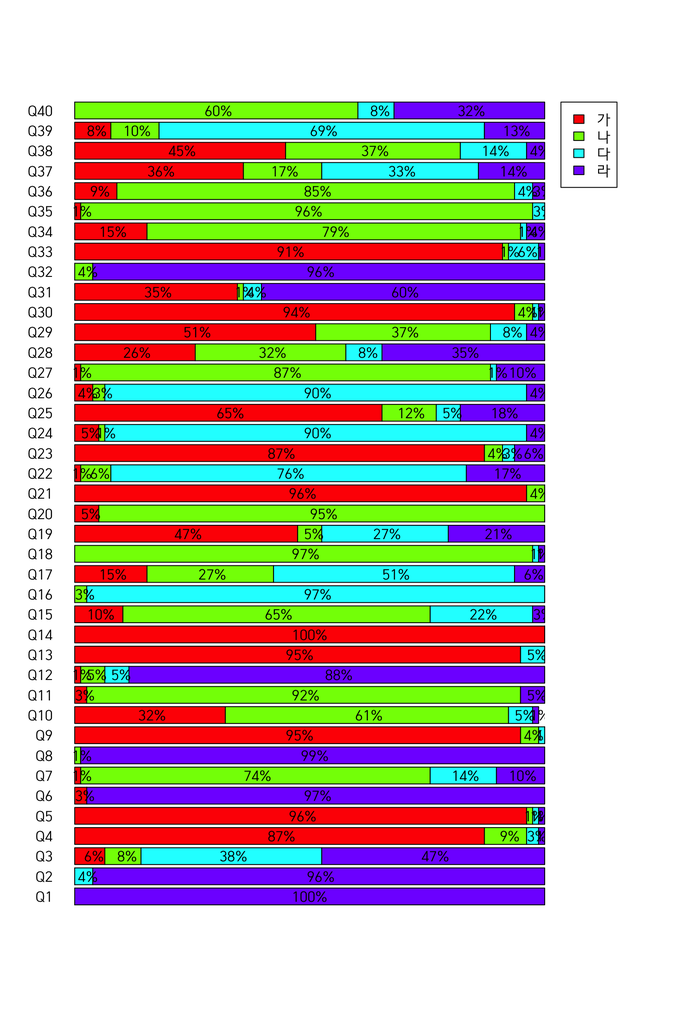

```r
text(x = midterm_tbl[1, ] / 2,
     y = b,
     labels = label_ptbl[1, ])
text(x = midterm_tbl[1, ] + midterm_tbl[2, ] / 2 ,
     y = b,
     labels = label_ptbl[2, ])
text(x = midterm_tbl[1, ] + midterm_tbl[2, ] + midterm_tbl[3, ] / 2,
     y = b,
     labels = label_ptbl[3, ])
text(x = midterm_tbl[1, ] + midterm_tbl[2, ] + midterm_tbl[3, ] + midterm_tbl[4, ]/ 2,
     y = b,
     labels = label_ptbl[4, ])
```

## 점수

정답과 맞춰보기 위해서는 정답을 읽어들여야 하는데 이를 위해서 `what = ""`로 설정하여 `char`취급.

```r
(ans <- scan("../data/midterm_ans.txt", what = ""))
```

```
##  [1] "라" "라" "라" "가" "가" "라" "나" "라" "가" "나" "나" "라" "가" "가" "나" "다" "다" "나" "가" "나" "가" "다" "가" "다" "가" "다" "나" "나" "가" "가" "가" "라" "가" "나" "나"
## [36] "나" "가" "나" "다" "나"
```

각 학생들의 답안과 맞춰보려면 정답표를 작성하여야 하는데 이렇게 하시 위해서 각 문항을 리스트의 원소로 분리하는데 이때 `split()` 의 기능과 한계에 유의. `factor` 성격으로부터 `1, 10, 11, ..., 2, 20, ..., 3, 4, 5, ... , 9`로 순서를 잡게 되므로 다시 한번 정리할 필요.

```r
(ans_l <- split(ans, f = paste("A", 1:40, sep = "")))
```

```
## $A1
## [1] "라"
##
## $A10
## [1] "나"
##
## $A11
## [1] "나"
##
## $A12
## [1] "라"
##
## $A13
## [1] "가"
##
## $A14
## [1] "가"
##
## $A15
## [1] "나"
##
## $A16
## [1] "다"
##
## $A17
## [1] "다"
##
## $A18
## [1] "나"
##
## $A19
## [1] "가"
##
## $A2
## [1] "라"
##
## $A20
## [1] "나"
##
## $A21
```

[output cut: 64 more lines]

```
##
## $A5
## [1] "가"
##
## $A6
## [1] "라"
##
## $A7
## [1] "나"
##
## $A8
## [1] "라"
##
## $A9
## [1] "가"
```

```r
(ans_l_2 <- ans_l[paste("A", 1:40, sep = "")])
```

```
## $A1
## [1] "라"
##
## $A2
## [1] "라"
##
## $A3
## [1] "라"
##
## $A4
## [1] "가"
##
## $A5
## [1] "가"
##
## $A6
## [1] "라"
##
## $A7
## [1] "나"
##
## $A8
## [1] "라"
##
## $A9
## [1] "가"
##
## $A10
## [1] "나"
##
## $A11
## [1] "나"
##
## $A12
## [1] "라"
##
## $A13
## [1] "가"
##
## $A14
```

[output cut: 64 more lines]

```
##
## $A36
## [1] "나"
##
## $A37
## [1] "가"
##
## $A38
## [1] "나"
##
## $A39
## [1] "다"
##
## $A40
## [1] "나"
```

### 정답과 대조하여 R(Right)/W(Wrong) 표시

채점표라는 의미의 `midterm_marks` 로 저장, (# 표시한 방식으로는 작동하지 않음)

```r
midterm_marks_rw <- mapply(function(x, y) factor(ifelse(x == y, "R", "W")), y = ans_l_2, midterm)
kable(midterm_marks_rw[, 1:20])
```

| A1 | A2 | A3 | A4 | A5 | A6 | A7 | A8 | A9 | A10 | A11 | A12 | A13 | A14 | A15 | A16 | A17 | A18 | A19 | A20 |
| --- | --- | --- | --- | --- | --- | --- | --- | --- | --- | --- | --- | --- | --- | --- | --- | --- | --- | --- | --- |
| R | R | W | R | R | R | W | R | R | W | R | W | R | R | W | R | W | R | W | R |
| R | R | R | R | R | R | R | R | R | R | R | R | R | R | W | R | R | R | R | W |
| R | R | R | R | R | R | R | R | R | R | R | R | R | R | R | R | W | R | R | R |
| R | R | R | R | R | W | R | R | R | W | R | R | R | R | W | R | R | R | R | R |
| R | R | R | R | R | R | R | R | R | R | R | R | R | R | R | R | R | R | R | R |
| R | R | R | W | R | R | R | R | R | R | R | W | R | R | R | R | R | R | R | R |
| R | R | W | R | R | R | R | R | R | R | R | R | R | R | R | R | R | R | W | R |
| R | R | W | R | R | R | W | R | R | R | W | R | W | R | R | R | W | R | W | R |
| R | R | W | R | R | R | R | R | R | R | R | R | R | R | R | R | W | R | W | R |
| R | R | W | R | R | R | W | R | R | W | R | W | R | R | R | R | W | R | W | R |
| R | R | W | R | R | R | R | R | R | R | R | R | R | R | R | R | R | R | W | R |
| R | R | W | R | R | R | R | R | R | R | R | R | R | R | R | R | R | R | W | R |
| R | R | W | R | R | R | W | R | R | R | R | R | R | R | R | R | R | R | R | R |
| R | R | W | W | R | R | W | R | R | W | R | R | R | R | W | R | R | R | R | R |
| R | R | R | R | R | R | R | R | R | R | R | R | R | R | R | R | R | W | W | R |
| R | R | W | R | R | R | R | R | R | R | W | R | R | R | R | R | R | R | R | R |
| R | R | R | R | R | R | R | R | R | W | R | R | R | R | R | R | W | R | W | R |
| R | R | W | R | R | R | R | R | R | R | R | R | R | R | W | R | R | R | W | R |
| R | R | R | R | R | R | R | R | R | W | R | R | R | R | R | R | W | R | W | R |
| R | R | R | R | R | R | R | R | R | W | R | R | R | R | R | R | R | R | R | R |
| R | R | W | R | R | R | R | R | R | R | R | R | R | R | R | R | R | R | R | R |
| R | R | R | R | R | R | R | R | R | R | R | R | R | R | R | R | W | R | R | R |
| R | R | R | R | R | R | W | R | R | R | W | R | R | R | R | R | R | R | W | R |
| R | R | W | R | R | R | R | R | R | W | R | R | R | R | R | R | W | R | R | R |
| R | W | W | R | R | R | R | R | R | R | R | W | R | R | W | R | R | R | W | W |
| R | R | W | R | R | R | R | R | R | R | R | R | R | R | R | R | W | R | W | R |
| R | R | W | R | W | R | R | R | R | W | R | R | R | R | R | R | W | R | R | R |
| R | R | R | R | R | R | R | R | R | R | R | R | R | R | R | R | R | R | R | R |
| R | R | W | R | R | R | W | R | W | W | R | R | R | R | W | R | W | R | R | R |
| R | R | W | R | R | R | R | R | R | W | R | R | R | R | R | R | W | R | R | R |
| R | R | R | R | R | R | R | R | R | R | R | R | R | R | R | R | R | R | R | R |
| R | R | R | R | R | W | W | R | R | W | R | R | R | R | W | R | R | R | W | R |
| R | R | W | R | R | R | R | R | R | W | R | R | R | R | R | R | R | R | R | R |
| R | W | W | R | R | R | R | R | R | NA | R | W | R | R | R | R | R | R | W | R |
| R | R | W | R | R | R | R | R | R | R | R | W | R | R | R | R | R | R | W | R |
| R | R | W | R | R | R | R | R | R | W | R | R | R | R | R | R | W | R | R | R |
| R | R | R | R | R | R | W | R | R | R | R | W | R | R | R | R | R | R | R | R |
| R | R | R | R | R | R | R | R | R | R | R | R | R | R | R | R | W | R | W | R |
| R | R | R | R | R | R | R | R | R | R | R | R | R | R | R | R | W | R | W | R |
| R | R | W | R | R | R | R | R | R | R | R | R | R | R | W | R | R | R | W | R |
| R | R | R | R | R | R | W | R | R | W | R | R | R | R | R | R | W | R | W | R |
| R | R | R | W | R | R | R | R | R | R | R | R | R | R | W | R | W | R | W | R |
| R | R | W | R | R | R | W | R | R | W | R | R | R | R | W | R | W | R | W | R |
| R | R | R | R | R | R | R | R | R | R | R | R | R | R | R | R | R | R | R | R |
| R | R | R | W | R | R | R | R | R | R | R | R | R | R | R | R | W | R | R | R |
| R | R | R | R | R | R | R | R | R | W | R | R | R | R | R | R | R | R | W | R |
| R | R | R | R | R | R | R | R | R | R | R | R | R | R | R | R | R | R | R | R |
| R | R | W | R | R | R | R | R | W | W | R | R | R | R | W | R | W | R | W | R |
| R | R | R | R | R | R | R | R | R | R | R | R | R | R | R | R | R | R | R | R |
| R | R | W | R | R | R | R | R | R | R | R | R | R | R | R | R | R | R | R | R |
| R | R | R | W | R | R | R | R | R | W | R | R | R | R | R | R | W | R | W | R |
| R | R | W | W | R | R | W | R | R | W | R | R | W | R | W | W | R | R | W | R |
| R | R | W | W | W | R | R | R | R | W | R | R | R | R | W | R | W | R | R | R |
| R | R | R | R | R | R | R | R | R | R | R | R | R | R | R | R | R | R | W | R |
| R | R | W | R | R | R | R | R | R | W | R | R | R | R | W | R | R | R | W | R |
| R | R | R | R | R | R | R | R | R | R | R | R | R | R | R | R | R | R | R | R |
| R | R | W | R | R | R | R | R | R | R | R | R | R | R | W | R | R | R | W | R |
| R | R | W | R | R | R | R | R | R | W | R | R | R | R | W | R | W | R | W | R |
| R | R | R | R | R | R | R | R | R | R | R | R | R | R | R | R | R | R | R | R |
| R | R | W | R | R | R | W | R | R | W | R | R | R | R | R | R | W | R | R | R |
| R | R | W | W | R | R | R | R | R | W | W | R | R | R | W | R | W | W | W | R |
| R | R | R | R | R | R | R | R | R | R | R | R | R | R | W | R | W | R | R | R |
| R | W | W | W | W | R | R | W | W | R | W | R | W | R | W | R | W | R | R | W |
| R | R | R | R | R | R | W | R | R | W | R | R | R | R | R | R | W | R | W | R |
| R | R | W | W | R | R | R | R | W | W | W | W | W | R | W | W | W | R | W | W |
| R | R | R | R | R | R | R | R | R | R | R | R | R | R | R | R | R | R | W | R |
| R | R | W | R | R | R | R | R | R | R | R | R | R | R | W | R | W | R | R | R |
| R | R | R | R | R | R | R | R | R | R | R | R | R | R | W | R | W | R | W | R |
| R | R | R | R | R | R | R | R | R | R | R | R | R | R | R | R | R | R | R | R |
| R | R | W | R | R | R | W | R | R | R | R | R | R | R | W | R | W | R | W | R |
| R | R | R | R | R | R | W | R | R | R | R | R | R | R | R | R | R | R | W | R |
| R | R | R | R | R | R | R | R | R | W | R | R | R | R | R | R | R | R | W | R |
| R | R | W | R | R | R | W | R | R | W | R | W | R | R | R | R | W | R | W | R |
| R | R | R | R | R | R | W | R | R | R | R | R | R | R | W | R | W | R | R | R |
| R | R | R | R | R | R | W | R | R | R | R | R | R | R | R | R | R | R | R | R |
| R | R | W | R | R | R | W | R | R | R | R | R | R | R | W | R | W | R | W | R |
| R | R | W | R | R | R | R | R | R | R | R | R | R | R | R | R | W | R | R | R |
| R | R | W | R | R | R | R | R | R | W | R | R | R | R | W | R | W | R | R | R |

```r
kable(midterm_marks_rw[, 21:40])
```

| A21 | A22 | A23 | A24 | A25 | A26 | A27 | A28 | A29 | A30 | A31 | A32 | A33 | A34 | A35 | A36 | A37 | A38 | A39 | A40 |
| --- | --- | --- | --- | --- | --- | --- | --- | --- | --- | --- | --- | --- | --- | --- | --- | --- | --- | --- | --- |
| R | R | R | R | R | R | R | W | W | R | W | R | R | R | R | R | R | W | R | W |
| W | R | W | R | W | R | R | W | W | R | R | R | R | R | R | R | W | R | R | W |
| R | R | R | R | W | R | R | R | W | R | R | R | R | R | W | R | R | R | R | R |
| R | R | R | R | R | R | R | W | R | R | R | R | R | R | R | W | W | W | R | R |
| R | R | R | R | R | R | W | R | W | R | W | R | R | R | R | R | W | W | R | R |
| R | R | R | R | R | R | R | W | W | R | R | R | R | R | R | R | W | R | R | W |
| R | W | R | R | R | W | R | R | R | R | W | R | R | R | R | R | W | W | R | R |
| R | R | W | W | R | R | R | R | R | W | W | R | W | R | R | R | W | R | W | W |
| R | R | R | R | W | R | R | W | R | R | W | R | R | W | R | R | W | W | R | W |
| R | W | R | W | W | R | R | W | R | R | R | R | R | W | R | R | W | R | R | W |
| R | R | R | R | W | R | R | R | R | R | W | R | R | R | R | R | W | W | R | W |
| R | R | R | R | W | R | R | W | W | R | W | R | R | R | R | R | W | W | R | R |
| R | R | R | R | R | R | R | W | R | R | R | R | R | R | R | R | W | W | R | R |
| R | R | R | R | R | R | W | W | W | R | W | R | R | R | R | R | W | W | W | W |
| R | R | R | R | R | R | R | R | R | R | W | R | R | R | R | R | R | R | R | R |
| R | R | R | R | R | R | R | W | R | R | W | R | R | R | R | W | W | W | R | W |
| R | R | R | R | W | R | R | W | W | R | W | R | R | R | R | R | W | W | W | R |
| R | R | R | R | R | R | R | W | R | R | W | R | R | R | R | R | R | W | R | R |
| R | R | R | R | W | R | R | R | W | R | W | R | R | R | R | R | R | R | W | W |
| R | R | R | R | R | R | R | R | R | R | W | R | R | R | R | R | R | W | R | R |
| R | W | R | W | R | W | R | W | R | R | W | R | R | R | R | R | R | R | R | W |
| R | W | R | R | R | W | W | R | W | R | W | R | R | R | R | R | W | W | R | R |
| R | R | R | R | W | R | R | W | W | R | R | R | R | R | R | R | W | W | R | W |
| R | R | R | R | R | R | R | W | W | R | W | R | R | R | R | R | W | W | R | W |
| R | R | W | W | R | R | R | W | R | R | W | W | W | W | R | R | W | W | W | W |
| R | R | R | R | R | R | R | R | W | R | R | R | R | R | R | R | W | R | R | R |
| R | R | R | R | R | R | R | R | W | R | W | R | R | R | R | R | R | W | W | R |
| R | W | R | R | R | R | R | R | R | R | W | R | R | R | R | R | R | R | R | R |
| R | R | R | R | R | R | W | W | W | R | W | R | R | W | R | R | W | R | R | R |
| R | R | R | R | R | R | R | W | R | R | R | R | R | R | R | R | R | R | R | R |
| R | W | R | R | W | R | R | W | W | R | W | R | R | R | R | R | W | W | R | R |
| R | R | R | R | W | R | R | W | R | R | W | R | R | R | R | R | R | W | R | R |
| R | W | W | R | W | R | R | W | W | R | W | R | R | R | R | W | W | W | W | R |
| R | R | R | R | R | R | W | W | R | W | W | W | W | R | R | R | W | W | W | W |
| R | R | R | R | R | R | R | R | R | R | W | R | R | R | R | R | R | W | R | R |
| W | W | W | R | R | W | R | W | R | R | W | R | W | W | R | R | R | W | W | R |
| R | W | R | R | R | R | R | W | R | R | W | R | R | R | R | R | R | R | R | R |
| R | R | R | R | R | R | R | W | W | R | R | R | R | R | R | R | W | W | R | R |
| R | R | R | R | R | R | R | R | R | R | R | R | R | R | R | R | W | W | R | R |
| R | R | R | R | R | R | R | W | R | R | R | R | R | R | R | R | R | R | R | R |
| R | W | R | R | W | R | R | W | W | R | W | R | R | W | R | R | W | W | W | W |
| R | R | W | R | W | R | R | R | R | R | R | R | R | W | R | W | W | W | R | R |
| R | R | R | R | R | R | R | W | W | R | R | R | R | R | R | R | R | W | R | R |
| R | W | R | R | R | R | R | R | R | R | R | R | R | R | R | R | R | R | R | R |
| R | R | R | R | R | R | R | W | R | R | W | R | R | R | R | R | R | R | R | R |
| R | R | R | R | R | R | R | R | W | R | R | R | R | W | R | R | W | W | R | R |
| R | R | R | R | R | R | R | R | R | R | R | R | R | R | R | R | R | W | R | R |
| R | R | R | R | R | R | R | W | W | R | R | R | R | R | R | W | W | W | W | W |
| R | R | R | R | R | R | R | W | R | R | R | R | R | R | R | W | W | R | R | W |
| R | R | R | R | R | R | R | W | R | R | W | R | R | R | R | R | W | W | R | R |
| R | W | R | R | W | R | R | W | W | R | R | R | R | R | R | R | W | R | W | R |
| R | R | R | R | W | R | R | W | W | W | W | R | W | R | R | R | R | R | W | W |
| R | W | W | R | W | R | R | W | W | R | W | R | W | R | R | W | R | W | W | W |
| R | R | R | R | W | R | R | W | W | R | W | R | R | W | R | R | W | W | W | R |
| R | R | W | R | R | R | R | R | W | R | W | R | R | W | R | W | W | W | R | R |
| R | R | R | R | R | R | R | W | R | R | R | R | R | R | R | R | W | W | R | W |
| R | W | R | R | R | R | R | W | R | R | W | R | R | R | R | R | R | W | W | W |
| R | R | R | R | W | R | R | W | R | R | W | R | R | R | R | R | R | W | W | R |
| R | R | R | R | R | R | R | R | R | R | R | R | R | R | R | R | R | R | R | W |
| R | W | R | R | R | R | R | W | W | R | W | R | R | R | R | R | W | W | R | R |
| R | W | R | W | R | R | R | R | W | R | W | R | R | R | R | R | W | R | R | R |
| R | W | R | R | R | R | W | W | W | R | W | R | R | R | R | W | R | R | W | W |
| R | R | W | W | W | W | R | W | W | W | W | R | W | W | W | R | W | R | W | W |
| R | R | R | W | W | R | R | W | W | R | W | R | R | W | R | R | W | W | R | R |
| W | R | R | W | W | W | W | W | W | W | W | W | R | W | R | W | W | W | W | W |
| R | R | R | R | R | R | R | W | R | R | R | R | R | R | R | R | W | R | R | R |
| R | R | W | R | R | R | R | R | R | R | R | R | R | R | R | R | W | R | R | R |
| R | W | R | R | W | W | R | R | R | R | W | R | R | R | R | R | W | W | R | R |
| R | R | R | R | W | R | R | W | R | R | R | R | R | R | W | R | R | R | R | R |
| R | R | R | R | W | R | R | W | W | R | W | R | R | R | R | R | W | W | R | R |
| R | R | R | R | R | R | R | R | W | R | R | R | R | R | R | R | W | R | R | R |
| R | R | R | R | W | R | R | W | W | R | W | R | R | W | R | W | W | R | W | W |
| R | R | R | R | R | W | R | W | R | R | W | R | R | R | R | R | W | W | R | W |
| R | R | R | R | R | R | R | W | W | R | W | R | R | R | R | R | W | W | W | R |
| R | R | R | R | R | R | W | W | W | R | W | R | R | R | R | R | R | R | R | W |
| R | R | R | R | R | R | W | R | R | R | W | R | R | W | R | R | W | W | W | R |
| R | R | R | R | R | R | W | W | R | R | R | R | R | R | R | W | R | W | W | W |
| R | W | R | R | W | R | R | W | R | R | W | R | R | W | R | R | W | W | R | W |

### 학생별 점수 산출

정답을 집계하기 위하여 “R” 갯수를 다시 산출하는 `ifelse()` 적용. 2.5점씩 곱하면 100점 만점 기준의 점수가 됨. 답안지는 작성해서 제출했지만 빈칸이 있는 경우는 그 문항을 0점 처리, 결석의 경우는 점수가 모두 0으로 나오는 경우를 `NA`처리

```r
midterm_marks <- ifelse(midterm_marks_rw == "R", 1, 0)
kable(midterm_marks[, 1:20])
```

| A1 | A2 | A3 | A4 | A5 | A6 | A7 | A8 | A9 | A10 | A11 | A12 | A13 | A14 | A15 | A16 | A17 | A18 | A19 | A20 |
| --- | --- | --- | --- | --- | --- | --- | --- | --- | --- | --- | --- | --- | --- | --- | --- | --- | --- | --- | --- |
| 1 | 1 | 0 | 1 | 1 | 1 | 0 | 1 | 1 | 0 | 1 | 0 | 1 | 1 | 0 | 1 | 0 | 1 | 0 | 1 |
| 1 | 1 | 1 | 1 | 1 | 1 | 1 | 1 | 1 | 1 | 1 | 1 | 1 | 1 | 0 | 1 | 1 | 1 | 1 | 0 |
| 1 | 1 | 1 | 1 | 1 | 1 | 1 | 1 | 1 | 1 | 1 | 1 | 1 | 1 | 1 | 1 | 0 | 1 | 1 | 1 |
| 1 | 1 | 1 | 1 | 1 | 0 | 1 | 1 | 1 | 0 | 1 | 1 | 1 | 1 | 0 | 1 | 1 | 1 | 1 | 1 |
| 1 | 1 | 1 | 1 | 1 | 1 | 1 | 1 | 1 | 1 | 1 | 1 | 1 | 1 | 1 | 1 | 1 | 1 | 1 | 1 |
| 1 | 1 | 1 | 0 | 1 | 1 | 1 | 1 | 1 | 1 | 1 | 0 | 1 | 1 | 1 | 1 | 1 | 1 | 1 | 1 |
| 1 | 1 | 0 | 1 | 1 | 1 | 1 | 1 | 1 | 1 | 1 | 1 | 1 | 1 | 1 | 1 | 1 | 1 | 0 | 1 |
| 1 | 1 | 0 | 1 | 1 | 1 | 0 | 1 | 1 | 1 | 0 | 1 | 0 | 1 | 1 | 1 | 0 | 1 | 0 | 1 |
| 1 | 1 | 0 | 1 | 1 | 1 | 1 | 1 | 1 | 1 | 1 | 1 | 1 | 1 | 1 | 1 | 0 | 1 | 0 | 1 |
| 1 | 1 | 0 | 1 | 1 | 1 | 0 | 1 | 1 | 0 | 1 | 0 | 1 | 1 | 1 | 1 | 0 | 1 | 0 | 1 |
| 1 | 1 | 0 | 1 | 1 | 1 | 1 | 1 | 1 | 1 | 1 | 1 | 1 | 1 | 1 | 1 | 1 | 1 | 0 | 1 |
| 1 | 1 | 0 | 1 | 1 | 1 | 1 | 1 | 1 | 1 | 1 | 1 | 1 | 1 | 1 | 1 | 1 | 1 | 0 | 1 |
| 1 | 1 | 0 | 1 | 1 | 1 | 0 | 1 | 1 | 1 | 1 | 1 | 1 | 1 | 1 | 1 | 1 | 1 | 1 | 1 |
| 1 | 1 | 0 | 0 | 1 | 1 | 0 | 1 | 1 | 0 | 1 | 1 | 1 | 1 | 0 | 1 | 1 | 1 | 1 | 1 |
| 1 | 1 | 1 | 1 | 1 | 1 | 1 | 1 | 1 | 1 | 1 | 1 | 1 | 1 | 1 | 1 | 1 | 0 | 0 | 1 |
| 1 | 1 | 0 | 1 | 1 | 1 | 1 | 1 | 1 | 1 | 0 | 1 | 1 | 1 | 1 | 1 | 1 | 1 | 1 | 1 |
| 1 | 1 | 1 | 1 | 1 | 1 | 1 | 1 | 1 | 0 | 1 | 1 | 1 | 1 | 1 | 1 | 0 | 1 | 0 | 1 |
| 1 | 1 | 0 | 1 | 1 | 1 | 1 | 1 | 1 | 1 | 1 | 1 | 1 | 1 | 0 | 1 | 1 | 1 | 0 | 1 |
| 1 | 1 | 1 | 1 | 1 | 1 | 1 | 1 | 1 | 0 | 1 | 1 | 1 | 1 | 1 | 1 | 0 | 1 | 0 | 1 |
| 1 | 1 | 1 | 1 | 1 | 1 | 1 | 1 | 1 | 0 | 1 | 1 | 1 | 1 | 1 | 1 | 1 | 1 | 1 | 1 |
| 1 | 1 | 0 | 1 | 1 | 1 | 1 | 1 | 1 | 1 | 1 | 1 | 1 | 1 | 1 | 1 | 1 | 1 | 1 | 1 |
| 1 | 1 | 1 | 1 | 1 | 1 | 1 | 1 | 1 | 1 | 1 | 1 | 1 | 1 | 1 | 1 | 0 | 1 | 1 | 1 |
| 1 | 1 | 1 | 1 | 1 | 1 | 0 | 1 | 1 | 1 | 0 | 1 | 1 | 1 | 1 | 1 | 1 | 1 | 0 | 1 |
| 1 | 1 | 0 | 1 | 1 | 1 | 1 | 1 | 1 | 0 | 1 | 1 | 1 | 1 | 1 | 1 | 0 | 1 | 1 | 1 |
| 1 | 0 | 0 | 1 | 1 | 1 | 1 | 1 | 1 | 1 | 1 | 0 | 1 | 1 | 0 | 1 | 1 | 1 | 0 | 0 |
| 1 | 1 | 0 | 1 | 1 | 1 | 1 | 1 | 1 | 1 | 1 | 1 | 1 | 1 | 1 | 1 | 0 | 1 | 0 | 1 |
| 1 | 1 | 0 | 1 | 0 | 1 | 1 | 1 | 1 | 0 | 1 | 1 | 1 | 1 | 1 | 1 | 0 | 1 | 1 | 1 |
| 1 | 1 | 1 | 1 | 1 | 1 | 1 | 1 | 1 | 1 | 1 | 1 | 1 | 1 | 1 | 1 | 1 | 1 | 1 | 1 |
| 1 | 1 | 0 | 1 | 1 | 1 | 0 | 1 | 0 | 0 | 1 | 1 | 1 | 1 | 0 | 1 | 0 | 1 | 1 | 1 |
| 1 | 1 | 0 | 1 | 1 | 1 | 1 | 1 | 1 | 0 | 1 | 1 | 1 | 1 | 1 | 1 | 0 | 1 | 1 | 1 |
| 1 | 1 | 1 | 1 | 1 | 1 | 1 | 1 | 1 | 1 | 1 | 1 | 1 | 1 | 1 | 1 | 1 | 1 | 1 | 1 |
| 1 | 1 | 1 | 1 | 1 | 0 | 0 | 1 | 1 | 0 | 1 | 1 | 1 | 1 | 0 | 1 | 1 | 1 | 0 | 1 |
| 1 | 1 | 0 | 1 | 1 | 1 | 1 | 1 | 1 | 0 | 1 | 1 | 1 | 1 | 1 | 1 | 1 | 1 | 1 | 1 |
| 1 | 0 | 0 | 1 | 1 | 1 | 1 | 1 | 1 | NA | 1 | 0 | 1 | 1 | 1 | 1 | 1 | 1 | 0 | 1 |
| 1 | 1 | 0 | 1 | 1 | 1 | 1 | 1 | 1 | 1 | 1 | 0 | 1 | 1 | 1 | 1 | 1 | 1 | 0 | 1 |
| 1 | 1 | 0 | 1 | 1 | 1 | 1 | 1 | 1 | 0 | 1 | 1 | 1 | 1 | 1 | 1 | 0 | 1 | 1 | 1 |
| 1 | 1 | 1 | 1 | 1 | 1 | 0 | 1 | 1 | 1 | 1 | 0 | 1 | 1 | 1 | 1 | 1 | 1 | 1 | 1 |
| 1 | 1 | 1 | 1 | 1 | 1 | 1 | 1 | 1 | 1 | 1 | 1 | 1 | 1 | 1 | 1 | 0 | 1 | 0 | 1 |
| 1 | 1 | 1 | 1 | 1 | 1 | 1 | 1 | 1 | 1 | 1 | 1 | 1 | 1 | 1 | 1 | 0 | 1 | 0 | 1 |
| 1 | 1 | 0 | 1 | 1 | 1 | 1 | 1 | 1 | 1 | 1 | 1 | 1 | 1 | 0 | 1 | 1 | 1 | 0 | 1 |
| 1 | 1 | 1 | 1 | 1 | 1 | 0 | 1 | 1 | 0 | 1 | 1 | 1 | 1 | 1 | 1 | 0 | 1 | 0 | 1 |
| 1 | 1 | 1 | 0 | 1 | 1 | 1 | 1 | 1 | 1 | 1 | 1 | 1 | 1 | 0 | 1 | 0 | 1 | 0 | 1 |
| 1 | 1 | 0 | 1 | 1 | 1 | 0 | 1 | 1 | 0 | 1 | 1 | 1 | 1 | 0 | 1 | 0 | 1 | 0 | 1 |
| 1 | 1 | 1 | 1 | 1 | 1 | 1 | 1 | 1 | 1 | 1 | 1 | 1 | 1 | 1 | 1 | 1 | 1 | 1 | 1 |
| 1 | 1 | 1 | 0 | 1 | 1 | 1 | 1 | 1 | 1 | 1 | 1 | 1 | 1 | 1 | 1 | 0 | 1 | 1 | 1 |
| 1 | 1 | 1 | 1 | 1 | 1 | 1 | 1 | 1 | 0 | 1 | 1 | 1 | 1 | 1 | 1 | 1 | 1 | 0 | 1 |
| 1 | 1 | 1 | 1 | 1 | 1 | 1 | 1 | 1 | 1 | 1 | 1 | 1 | 1 | 1 | 1 | 1 | 1 | 1 | 1 |
| 1 | 1 | 0 | 1 | 1 | 1 | 1 | 1 | 0 | 0 | 1 | 1 | 1 | 1 | 0 | 1 | 0 | 1 | 0 | 1 |
| 1 | 1 | 1 | 1 | 1 | 1 | 1 | 1 | 1 | 1 | 1 | 1 | 1 | 1 | 1 | 1 | 1 | 1 | 1 | 1 |
| 1 | 1 | 0 | 1 | 1 | 1 | 1 | 1 | 1 | 1 | 1 | 1 | 1 | 1 | 1 | 1 | 1 | 1 | 1 | 1 |
| 1 | 1 | 1 | 0 | 1 | 1 | 1 | 1 | 1 | 0 | 1 | 1 | 1 | 1 | 1 | 1 | 0 | 1 | 0 | 1 |
| 1 | 1 | 0 | 0 | 1 | 1 | 0 | 1 | 1 | 0 | 1 | 1 | 0 | 1 | 0 | 0 | 1 | 1 | 0 | 1 |
| 1 | 1 | 0 | 0 | 0 | 1 | 1 | 1 | 1 | 0 | 1 | 1 | 1 | 1 | 0 | 1 | 0 | 1 | 1 | 1 |
| 1 | 1 | 1 | 1 | 1 | 1 | 1 | 1 | 1 | 1 | 1 | 1 | 1 | 1 | 1 | 1 | 1 | 1 | 0 | 1 |
| 1 | 1 | 0 | 1 | 1 | 1 | 1 | 1 | 1 | 0 | 1 | 1 | 1 | 1 | 0 | 1 | 1 | 1 | 0 | 1 |
| 1 | 1 | 1 | 1 | 1 | 1 | 1 | 1 | 1 | 1 | 1 | 1 | 1 | 1 | 1 | 1 | 1 | 1 | 1 | 1 |
| 1 | 1 | 0 | 1 | 1 | 1 | 1 | 1 | 1 | 1 | 1 | 1 | 1 | 1 | 0 | 1 | 1 | 1 | 0 | 1 |
| 1 | 1 | 0 | 1 | 1 | 1 | 1 | 1 | 1 | 0 | 1 | 1 | 1 | 1 | 0 | 1 | 0 | 1 | 0 | 1 |
| 1 | 1 | 1 | 1 | 1 | 1 | 1 | 1 | 1 | 1 | 1 | 1 | 1 | 1 | 1 | 1 | 1 | 1 | 1 | 1 |
| 1 | 1 | 0 | 1 | 1 | 1 | 0 | 1 | 1 | 0 | 1 | 1 | 1 | 1 | 1 | 1 | 0 | 1 | 1 | 1 |
| 1 | 1 | 0 | 0 | 1 | 1 | 1 | 1 | 1 | 0 | 0 | 1 | 1 | 1 | 0 | 1 | 0 | 0 | 0 | 1 |
| 1 | 1 | 1 | 1 | 1 | 1 | 1 | 1 | 1 | 1 | 1 | 1 | 1 | 1 | 0 | 1 | 0 | 1 | 1 | 1 |
| 1 | 0 | 0 | 0 | 0 | 1 | 1 | 0 | 0 | 1 | 0 | 1 | 0 | 1 | 0 | 1 | 0 | 1 | 1 | 0 |
| 1 | 1 | 1 | 1 | 1 | 1 | 0 | 1 | 1 | 0 | 1 | 1 | 1 | 1 | 1 | 1 | 0 | 1 | 0 | 1 |
| 1 | 1 | 0 | 0 | 1 | 1 | 1 | 1 | 0 | 0 | 0 | 0 | 0 | 1 | 0 | 0 | 0 | 1 | 0 | 0 |
| 1 | 1 | 1 | 1 | 1 | 1 | 1 | 1 | 1 | 1 | 1 | 1 | 1 | 1 | 1 | 1 | 1 | 1 | 0 | 1 |
| 1 | 1 | 0 | 1 | 1 | 1 | 1 | 1 | 1 | 1 | 1 | 1 | 1 | 1 | 0 | 1 | 0 | 1 | 1 | 1 |
| 1 | 1 | 1 | 1 | 1 | 1 | 1 | 1 | 1 | 1 | 1 | 1 | 1 | 1 | 0 | 1 | 0 | 1 | 0 | 1 |
| 1 | 1 | 1 | 1 | 1 | 1 | 1 | 1 | 1 | 1 | 1 | 1 | 1 | 1 | 1 | 1 | 1 | 1 | 1 | 1 |
| 1 | 1 | 0 | 1 | 1 | 1 | 0 | 1 | 1 | 1 | 1 | 1 | 1 | 1 | 0 | 1 | 0 | 1 | 0 | 1 |
| 1 | 1 | 1 | 1 | 1 | 1 | 0 | 1 | 1 | 1 | 1 | 1 | 1 | 1 | 1 | 1 | 1 | 1 | 0 | 1 |
| 1 | 1 | 1 | 1 | 1 | 1 | 1 | 1 | 1 | 0 | 1 | 1 | 1 | 1 | 1 | 1 | 1 | 1 | 0 | 1 |
| 1 | 1 | 0 | 1 | 1 | 1 | 0 | 1 | 1 | 0 | 1 | 0 | 1 | 1 | 1 | 1 | 0 | 1 | 0 | 1 |
| 1 | 1 | 1 | 1 | 1 | 1 | 0 | 1 | 1 | 1 | 1 | 1 | 1 | 1 | 0 | 1 | 0 | 1 | 1 | 1 |
| 1 | 1 | 1 | 1 | 1 | 1 | 0 | 1 | 1 | 1 | 1 | 1 | 1 | 1 | 1 | 1 | 1 | 1 | 1 | 1 |
| 1 | 1 | 0 | 1 | 1 | 1 | 0 | 1 | 1 | 1 | 1 | 1 | 1 | 1 | 0 | 1 | 0 | 1 | 0 | 1 |
| 1 | 1 | 0 | 1 | 1 | 1 | 1 | 1 | 1 | 1 | 1 | 1 | 1 | 1 | 1 | 1 | 0 | 1 | 1 | 1 |
| 1 | 1 | 0 | 1 | 1 | 1 | 1 | 1 | 1 | 0 | 1 | 1 | 1 | 1 | 0 | 1 | 0 | 1 | 1 | 1 |

```r
kable(midterm_marks[, 21:40])
```

| A21 | A22 | A23 | A24 | A25 | A26 | A27 | A28 | A29 | A30 | A31 | A32 | A33 | A34 | A35 | A36 | A37 | A38 | A39 | A40 |
| --- | --- | --- | --- | --- | --- | --- | --- | --- | --- | --- | --- | --- | --- | --- | --- | --- | --- | --- | --- |
| 1 | 1 | 1 | 1 | 1 | 1 | 1 | 0 | 0 | 1 | 0 | 1 | 1 | 1 | 1 | 1 | 1 | 0 | 1 | 0 |
| 0 | 1 | 0 | 1 | 0 | 1 | 1 | 0 | 0 | 1 | 1 | 1 | 1 | 1 | 1 | 1 | 0 | 1 | 1 | 0 |
| 1 | 1 | 1 | 1 | 0 | 1 | 1 | 1 | 0 | 1 | 1 | 1 | 1 | 1 | 0 | 1 | 1 | 1 | 1 | 1 |
| 1 | 1 | 1 | 1 | 1 | 1 | 1 | 0 | 1 | 1 | 1 | 1 | 1 | 1 | 1 | 0 | 0 | 0 | 1 | 1 |
| 1 | 1 | 1 | 1 | 1 | 1 | 0 | 1 | 0 | 1 | 0 | 1 | 1 | 1 | 1 | 1 | 0 | 0 | 1 | 1 |
| 1 | 1 | 1 | 1 | 1 | 1 | 1 | 0 | 0 | 1 | 1 | 1 | 1 | 1 | 1 | 1 | 0 | 1 | 1 | 0 |
| 1 | 0 | 1 | 1 | 1 | 0 | 1 | 1 | 1 | 1 | 0 | 1 | 1 | 1 | 1 | 1 | 0 | 0 | 1 | 1 |
| 1 | 1 | 0 | 0 | 1 | 1 | 1 | 1 | 1 | 0 | 0 | 1 | 0 | 1 | 1 | 1 | 0 | 1 | 0 | 0 |
| 1 | 1 | 1 | 1 | 0 | 1 | 1 | 0 | 1 | 1 | 0 | 1 | 1 | 0 | 1 | 1 | 0 | 0 | 1 | 0 |
| 1 | 0 | 1 | 0 | 0 | 1 | 1 | 0 | 1 | 1 | 1 | 1 | 1 | 0 | 1 | 1 | 0 | 1 | 1 | 0 |
| 1 | 1 | 1 | 1 | 0 | 1 | 1 | 1 | 1 | 1 | 0 | 1 | 1 | 1 | 1 | 1 | 0 | 0 | 1 | 0 |
| 1 | 1 | 1 | 1 | 0 | 1 | 1 | 0 | 0 | 1 | 0 | 1 | 1 | 1 | 1 | 1 | 0 | 0 | 1 | 1 |
| 1 | 1 | 1 | 1 | 1 | 1 | 1 | 0 | 1 | 1 | 1 | 1 | 1 | 1 | 1 | 1 | 0 | 0 | 1 | 1 |
| 1 | 1 | 1 | 1 | 1 | 1 | 0 | 0 | 0 | 1 | 0 | 1 | 1 | 1 | 1 | 1 | 0 | 0 | 0 | 0 |
| 1 | 1 | 1 | 1 | 1 | 1 | 1 | 1 | 1 | 1 | 0 | 1 | 1 | 1 | 1 | 1 | 1 | 1 | 1 | 1 |
| 1 | 1 | 1 | 1 | 1 | 1 | 1 | 0 | 1 | 1 | 0 | 1 | 1 | 1 | 1 | 0 | 0 | 0 | 1 | 0 |
| 1 | 1 | 1 | 1 | 0 | 1 | 1 | 0 | 0 | 1 | 0 | 1 | 1 | 1 | 1 | 1 | 0 | 0 | 0 | 1 |
| 1 | 1 | 1 | 1 | 1 | 1 | 1 | 0 | 1 | 1 | 0 | 1 | 1 | 1 | 1 | 1 | 1 | 0 | 1 | 1 |
| 1 | 1 | 1 | 1 | 0 | 1 | 1 | 1 | 0 | 1 | 0 | 1 | 1 | 1 | 1 | 1 | 1 | 1 | 0 | 0 |
| 1 | 1 | 1 | 1 | 1 | 1 | 1 | 1 | 1 | 1 | 0 | 1 | 1 | 1 | 1 | 1 | 1 | 0 | 1 | 1 |
| 1 | 0 | 1 | 0 | 1 | 0 | 1 | 0 | 1 | 1 | 0 | 1 | 1 | 1 | 1 | 1 | 1 | 1 | 1 | 0 |
| 1 | 0 | 1 | 1 | 1 | 0 | 0 | 1 | 0 | 1 | 0 | 1 | 1 | 1 | 1 | 1 | 0 | 0 | 1 | 1 |
| 1 | 1 | 1 | 1 | 0 | 1 | 1 | 0 | 0 | 1 | 1 | 1 | 1 | 1 | 1 | 1 | 0 | 0 | 1 | 0 |
| 1 | 1 | 1 | 1 | 1 | 1 | 1 | 0 | 0 | 1 | 0 | 1 | 1 | 1 | 1 | 1 | 0 | 0 | 1 | 0 |
| 1 | 1 | 0 | 0 | 1 | 1 | 1 | 0 | 1 | 1 | 0 | 0 | 0 | 0 | 1 | 1 | 0 | 0 | 0 | 0 |
| 1 | 1 | 1 | 1 | 1 | 1 | 1 | 1 | 0 | 1 | 1 | 1 | 1 | 1 | 1 | 1 | 0 | 1 | 1 | 1 |
| 1 | 1 | 1 | 1 | 1 | 1 | 1 | 1 | 0 | 1 | 0 | 1 | 1 | 1 | 1 | 1 | 1 | 0 | 0 | 1 |
| 1 | 0 | 1 | 1 | 1 | 1 | 1 | 1 | 1 | 1 | 0 | 1 | 1 | 1 | 1 | 1 | 1 | 1 | 1 | 1 |
| 1 | 1 | 1 | 1 | 1 | 1 | 0 | 0 | 0 | 1 | 0 | 1 | 1 | 0 | 1 | 1 | 0 | 1 | 1 | 1 |
| 1 | 1 | 1 | 1 | 1 | 1 | 1 | 0 | 1 | 1 | 1 | 1 | 1 | 1 | 1 | 1 | 1 | 1 | 1 | 1 |
| 1 | 0 | 1 | 1 | 0 | 1 | 1 | 0 | 0 | 1 | 0 | 1 | 1 | 1 | 1 | 1 | 0 | 0 | 1 | 1 |
| 1 | 1 | 1 | 1 | 0 | 1 | 1 | 0 | 1 | 1 | 0 | 1 | 1 | 1 | 1 | 1 | 1 | 0 | 1 | 1 |
| 1 | 0 | 0 | 1 | 0 | 1 | 1 | 0 | 0 | 1 | 0 | 1 | 1 | 1 | 1 | 0 | 0 | 0 | 0 | 1 |
| 1 | 1 | 1 | 1 | 1 | 1 | 0 | 0 | 1 | 0 | 0 | 0 | 0 | 1 | 1 | 1 | 0 | 0 | 0 | 0 |
| 1 | 1 | 1 | 1 | 1 | 1 | 1 | 1 | 1 | 1 | 0 | 1 | 1 | 1 | 1 | 1 | 1 | 0 | 1 | 1 |
| 0 | 0 | 0 | 1 | 1 | 0 | 1 | 0 | 1 | 1 | 0 | 1 | 0 | 0 | 1 | 1 | 1 | 0 | 0 | 1 |
| 1 | 0 | 1 | 1 | 1 | 1 | 1 | 0 | 1 | 1 | 0 | 1 | 1 | 1 | 1 | 1 | 1 | 1 | 1 | 1 |
| 1 | 1 | 1 | 1 | 1 | 1 | 1 | 0 | 0 | 1 | 1 | 1 | 1 | 1 | 1 | 1 | 0 | 0 | 1 | 1 |
| 1 | 1 | 1 | 1 | 1 | 1 | 1 | 1 | 1 | 1 | 1 | 1 | 1 | 1 | 1 | 1 | 0 | 0 | 1 | 1 |
| 1 | 1 | 1 | 1 | 1 | 1 | 1 | 0 | 1 | 1 | 1 | 1 | 1 | 1 | 1 | 1 | 1 | 1 | 1 | 1 |
| 1 | 0 | 1 | 1 | 0 | 1 | 1 | 0 | 0 | 1 | 0 | 1 | 1 | 0 | 1 | 1 | 0 | 0 | 0 | 0 |
| 1 | 1 | 0 | 1 | 0 | 1 | 1 | 1 | 1 | 1 | 1 | 1 | 1 | 0 | 1 | 0 | 0 | 0 | 1 | 1 |
| 1 | 1 | 1 | 1 | 1 | 1 | 1 | 0 | 0 | 1 | 1 | 1 | 1 | 1 | 1 | 1 | 1 | 0 | 1 | 1 |
| 1 | 0 | 1 | 1 | 1 | 1 | 1 | 1 | 1 | 1 | 1 | 1 | 1 | 1 | 1 | 1 | 1 | 1 | 1 | 1 |
| 1 | 1 | 1 | 1 | 1 | 1 | 1 | 0 | 1 | 1 | 0 | 1 | 1 | 1 | 1 | 1 | 1 | 1 | 1 | 1 |
| 1 | 1 | 1 | 1 | 1 | 1 | 1 | 1 | 0 | 1 | 1 | 1 | 1 | 0 | 1 | 1 | 0 | 0 | 1 | 1 |
| 1 | 1 | 1 | 1 | 1 | 1 | 1 | 1 | 1 | 1 | 1 | 1 | 1 | 1 | 1 | 1 | 1 | 0 | 1 | 1 |
| 1 | 1 | 1 | 1 | 1 | 1 | 1 | 0 | 0 | 1 | 1 | 1 | 1 | 1 | 1 | 0 | 0 | 0 | 0 | 0 |
| 1 | 1 | 1 | 1 | 1 | 1 | 1 | 0 | 1 | 1 | 1 | 1 | 1 | 1 | 1 | 0 | 0 | 1 | 1 | 0 |
| 1 | 1 | 1 | 1 | 1 | 1 | 1 | 0 | 1 | 1 | 0 | 1 | 1 | 1 | 1 | 1 | 0 | 0 | 1 | 1 |
| 1 | 0 | 1 | 1 | 0 | 1 | 1 | 0 | 0 | 1 | 1 | 1 | 1 | 1 | 1 | 1 | 0 | 1 | 0 | 1 |
| 1 | 1 | 1 | 1 | 0 | 1 | 1 | 0 | 0 | 0 | 0 | 1 | 0 | 1 | 1 | 1 | 1 | 1 | 0 | 0 |
| 1 | 0 | 0 | 1 | 0 | 1 | 1 | 0 | 0 | 1 | 0 | 1 | 0 | 1 | 1 | 0 | 1 | 0 | 0 | 0 |
| 1 | 1 | 1 | 1 | 0 | 1 | 1 | 0 | 0 | 1 | 0 | 1 | 1 | 0 | 1 | 1 | 0 | 0 | 0 | 1 |
| 1 | 1 | 0 | 1 | 1 | 1 | 1 | 1 | 0 | 1 | 0 | 1 | 1 | 0 | 1 | 0 | 0 | 0 | 1 | 1 |
| 1 | 1 | 1 | 1 | 1 | 1 | 1 | 0 | 1 | 1 | 1 | 1 | 1 | 1 | 1 | 1 | 0 | 0 | 1 | 0 |
| 1 | 0 | 1 | 1 | 1 | 1 | 1 | 0 | 1 | 1 | 0 | 1 | 1 | 1 | 1 | 1 | 1 | 0 | 0 | 0 |
| 1 | 1 | 1 | 1 | 0 | 1 | 1 | 0 | 1 | 1 | 0 | 1 | 1 | 1 | 1 | 1 | 1 | 0 | 0 | 1 |
| 1 | 1 | 1 | 1 | 1 | 1 | 1 | 1 | 1 | 1 | 1 | 1 | 1 | 1 | 1 | 1 | 1 | 1 | 1 | 0 |
| 1 | 0 | 1 | 1 | 1 | 1 | 1 | 0 | 0 | 1 | 0 | 1 | 1 | 1 | 1 | 1 | 0 | 0 | 1 | 1 |
| 1 | 0 | 1 | 0 | 1 | 1 | 1 | 1 | 0 | 1 | 0 | 1 | 1 | 1 | 1 | 1 | 0 | 1 | 1 | 1 |
| 1 | 0 | 1 | 1 | 1 | 1 | 0 | 0 | 0 | 1 | 0 | 1 | 1 | 1 | 1 | 0 | 1 | 1 | 0 | 0 |
| 1 | 1 | 0 | 0 | 0 | 0 | 1 | 0 | 0 | 0 | 0 | 1 | 0 | 0 | 0 | 1 | 0 | 1 | 0 | 0 |
| 1 | 1 | 1 | 0 | 0 | 1 | 1 | 0 | 0 | 1 | 0 | 1 | 1 | 0 | 1 | 1 | 0 | 0 | 1 | 1 |
| 0 | 1 | 1 | 0 | 0 | 0 | 0 | 0 | 0 | 0 | 0 | 0 | 1 | 0 | 1 | 0 | 0 | 0 | 0 | 0 |
| 1 | 1 | 1 | 1 | 1 | 1 | 1 | 0 | 1 | 1 | 1 | 1 | 1 | 1 | 1 | 1 | 0 | 1 | 1 | 1 |
| 1 | 1 | 0 | 1 | 1 | 1 | 1 | 1 | 1 | 1 | 1 | 1 | 1 | 1 | 1 | 1 | 0 | 1 | 1 | 1 |
| 1 | 0 | 1 | 1 | 0 | 0 | 1 | 1 | 1 | 1 | 0 | 1 | 1 | 1 | 1 | 1 | 0 | 0 | 1 | 1 |
| 1 | 1 | 1 | 1 | 0 | 1 | 1 | 0 | 1 | 1 | 1 | 1 | 1 | 1 | 0 | 1 | 1 | 1 | 1 | 1 |
| 1 | 1 | 1 | 1 | 0 | 1 | 1 | 0 | 0 | 1 | 0 | 1 | 1 | 1 | 1 | 1 | 0 | 0 | 1 | 1 |
| 1 | 1 | 1 | 1 | 1 | 1 | 1 | 1 | 0 | 1 | 1 | 1 | 1 | 1 | 1 | 1 | 0 | 1 | 1 | 1 |
| 1 | 1 | 1 | 1 | 0 | 1 | 1 | 0 | 0 | 1 | 0 | 1 | 1 | 0 | 1 | 0 | 0 | 1 | 0 | 0 |
| 1 | 1 | 1 | 1 | 1 | 0 | 1 | 0 | 1 | 1 | 0 | 1 | 1 | 1 | 1 | 1 | 0 | 0 | 1 | 0 |
| 1 | 1 | 1 | 1 | 1 | 1 | 1 | 0 | 0 | 1 | 0 | 1 | 1 | 1 | 1 | 1 | 0 | 0 | 0 | 1 |
| 1 | 1 | 1 | 1 | 1 | 1 | 0 | 0 | 0 | 1 | 0 | 1 | 1 | 1 | 1 | 1 | 1 | 1 | 1 | 0 |
| 1 | 1 | 1 | 1 | 1 | 1 | 0 | 1 | 1 | 1 | 0 | 1 | 1 | 0 | 1 | 1 | 0 | 0 | 0 | 1 |
| 1 | 1 | 1 | 1 | 1 | 1 | 0 | 0 | 1 | 1 | 1 | 1 | 1 | 1 | 1 | 0 | 1 | 0 | 0 | 0 |
| 1 | 0 | 1 | 1 | 0 | 1 | 1 | 0 | 1 | 1 | 0 | 1 | 1 | 0 | 1 | 1 | 0 | 0 | 1 | 0 |

```r
midterm_score <- midterm_marks * 2.5
kable(data.frame("순번" = 1:nrow(midterm), midterm_score)[1:20])
```

| 순번 | A1 | A2 | A3 | A4 | A5 | A6 | A7 | A8 | A9 | A10 | A11 | A12 | A13 | A14 | A15 | A16 | A17 | A18 | A19 |
| --- | --- | --- | --- | --- | --- | --- | --- | --- | --- | --- | --- | --- | --- | --- | --- | --- | --- | --- | --- |
| 1 | 2.5 | 2.5 | 0.0 | 2.5 | 2.5 | 2.5 | 0.0 | 2.5 | 2.5 | 0.0 | 2.5 | 0.0 | 2.5 | 2.5 | 0.0 | 2.5 | 0.0 | 2.5 | 0.0 |
| 2 | 2.5 | 2.5 | 2.5 | 2.5 | 2.5 | 2.5 | 2.5 | 2.5 | 2.5 | 2.5 | 2.5 | 2.5 | 2.5 | 2.5 | 0.0 | 2.5 | 2.5 | 2.5 | 2.5 |
| 3 | 2.5 | 2.5 | 2.5 | 2.5 | 2.5 | 2.5 | 2.5 | 2.5 | 2.5 | 2.5 | 2.5 | 2.5 | 2.5 | 2.5 | 2.5 | 2.5 | 0.0 | 2.5 | 2.5 |
| 4 | 2.5 | 2.5 | 2.5 | 2.5 | 2.5 | 0.0 | 2.5 | 2.5 | 2.5 | 0.0 | 2.5 | 2.5 | 2.5 | 2.5 | 0.0 | 2.5 | 2.5 | 2.5 | 2.5 |
| 5 | 2.5 | 2.5 | 2.5 | 2.5 | 2.5 | 2.5 | 2.5 | 2.5 | 2.5 | 2.5 | 2.5 | 2.5 | 2.5 | 2.5 | 2.5 | 2.5 | 2.5 | 2.5 | 2.5 |
| 6 | 2.5 | 2.5 | 2.5 | 0.0 | 2.5 | 2.5 | 2.5 | 2.5 | 2.5 | 2.5 | 2.5 | 0.0 | 2.5 | 2.5 | 2.5 | 2.5 | 2.5 | 2.5 | 2.5 |
| 7 | 2.5 | 2.5 | 0.0 | 2.5 | 2.5 | 2.5 | 2.5 | 2.5 | 2.5 | 2.5 | 2.5 | 2.5 | 2.5 | 2.5 | 2.5 | 2.5 | 2.5 | 2.5 | 0.0 |
| 8 | 2.5 | 2.5 | 0.0 | 2.5 | 2.5 | 2.5 | 0.0 | 2.5 | 2.5 | 2.5 | 0.0 | 2.5 | 0.0 | 2.5 | 2.5 | 2.5 | 0.0 | 2.5 | 0.0 |
| 9 | 2.5 | 2.5 | 0.0 | 2.5 | 2.5 | 2.5 | 2.5 | 2.5 | 2.5 | 2.5 | 2.5 | 2.5 | 2.5 | 2.5 | 2.5 | 2.5 | 0.0 | 2.5 | 0.0 |
| 10 | 2.5 | 2.5 | 0.0 | 2.5 | 2.5 | 2.5 | 0.0 | 2.5 | 2.5 | 0.0 | 2.5 | 0.0 | 2.5 | 2.5 | 2.5 | 2.5 | 0.0 | 2.5 | 0.0 |
| 11 | 2.5 | 2.5 | 0.0 | 2.5 | 2.5 | 2.5 | 2.5 | 2.5 | 2.5 | 2.5 | 2.5 | 2.5 | 2.5 | 2.5 | 2.5 | 2.5 | 2.5 | 2.5 | 0.0 |
| 12 | 2.5 | 2.5 | 0.0 | 2.5 | 2.5 | 2.5 | 2.5 | 2.5 | 2.5 | 2.5 | 2.5 | 2.5 | 2.5 | 2.5 | 2.5 | 2.5 | 2.5 | 2.5 | 0.0 |
| 13 | 2.5 | 2.5 | 0.0 | 2.5 | 2.5 | 2.5 | 0.0 | 2.5 | 2.5 | 2.5 | 2.5 | 2.5 | 2.5 | 2.5 | 2.5 | 2.5 | 2.5 | 2.5 | 2.5 |
| 14 | 2.5 | 2.5 | 0.0 | 0.0 | 2.5 | 2.5 | 0.0 | 2.5 | 2.5 | 0.0 | 2.5 | 2.5 | 2.5 | 2.5 | 0.0 | 2.5 | 2.5 | 2.5 | 2.5 |
| 15 | 2.5 | 2.5 | 2.5 | 2.5 | 2.5 | 2.5 | 2.5 | 2.5 | 2.5 | 2.5 | 2.5 | 2.5 | 2.5 | 2.5 | 2.5 | 2.5 | 2.5 | 0.0 | 0.0 |
| 16 | 2.5 | 2.5 | 0.0 | 2.5 | 2.5 | 2.5 | 2.5 | 2.5 | 2.5 | 2.5 | 0.0 | 2.5 | 2.5 | 2.5 | 2.5 | 2.5 | 2.5 | 2.5 | 2.5 |
| 17 | 2.5 | 2.5 | 2.5 | 2.5 | 2.5 | 2.5 | 2.5 | 2.5 | 2.5 | 0.0 | 2.5 | 2.5 | 2.5 | 2.5 | 2.5 | 2.5 | 0.0 | 2.5 | 0.0 |
| 18 | 2.5 | 2.5 | 0.0 | 2.5 | 2.5 | 2.5 | 2.5 | 2.5 | 2.5 | 2.5 | 2.5 | 2.5 | 2.5 | 2.5 | 0.0 | 2.5 | 2.5 | 2.5 | 0.0 |
| 19 | 2.5 | 2.5 | 2.5 | 2.5 | 2.5 | 2.5 | 2.5 | 2.5 | 2.5 | 0.0 | 2.5 | 2.5 | 2.5 | 2.5 | 2.5 | 2.5 | 0.0 | 2.5 | 0.0 |
| 20 | 2.5 | 2.5 | 2.5 | 2.5 | 2.5 | 2.5 | 2.5 | 2.5 | 2.5 | 0.0 | 2.5 | 2.5 | 2.5 | 2.5 | 2.5 | 2.5 | 2.5 | 2.5 | 2.5 |
| 21 | 2.5 | 2.5 | 0.0 | 2.5 | 2.5 | 2.5 | 2.5 | 2.5 | 2.5 | 2.5 | 2.5 | 2.5 | 2.5 | 2.5 | 2.5 | 2.5 | 2.5 | 2.5 | 2.5 |
| 22 | 2.5 | 2.5 | 2.5 | 2.5 | 2.5 | 2.5 | 2.5 | 2.5 | 2.5 | 2.5 | 2.5 | 2.5 | 2.5 | 2.5 | 2.5 | 2.5 | 0.0 | 2.5 | 2.5 |
| 23 | 2.5 | 2.5 | 2.5 | 2.5 | 2.5 | 2.5 | 0.0 | 2.5 | 2.5 | 2.5 | 0.0 | 2.5 | 2.5 | 2.5 | 2.5 | 2.5 | 2.5 | 2.5 | 0.0 |
| 24 | 2.5 | 2.5 | 0.0 | 2.5 | 2.5 | 2.5 | 2.5 | 2.5 | 2.5 | 0.0 | 2.5 | 2.5 | 2.5 | 2.5 | 2.5 | 2.5 | 0.0 | 2.5 | 2.5 |
| 25 | 2.5 | 0.0 | 0.0 | 2.5 | 2.5 | 2.5 | 2.5 | 2.5 | 2.5 | 2.5 | 2.5 | 0.0 | 2.5 | 2.5 | 0.0 | 2.5 | 2.5 | 2.5 | 0.0 |
| 26 | 2.5 | 2.5 | 0.0 | 2.5 | 2.5 | 2.5 | 2.5 | 2.5 | 2.5 | 2.5 | 2.5 | 2.5 | 2.5 | 2.5 | 2.5 | 2.5 | 0.0 | 2.5 | 0.0 |
| 27 | 2.5 | 2.5 | 0.0 | 2.5 | 0.0 | 2.5 | 2.5 | 2.5 | 2.5 | 0.0 | 2.5 | 2.5 | 2.5 | 2.5 | 2.5 | 2.5 | 0.0 | 2.5 | 2.5 |
| 28 | 2.5 | 2.5 | 2.5 | 2.5 | 2.5 | 2.5 | 2.5 | 2.5 | 2.5 | 2.5 | 2.5 | 2.5 | 2.5 | 2.5 | 2.5 | 2.5 | 2.5 | 2.5 | 2.5 |
| 29 | 2.5 | 2.5 | 0.0 | 2.5 | 2.5 | 2.5 | 0.0 | 2.5 | 0.0 | 0.0 | 2.5 | 2.5 | 2.5 | 2.5 | 0.0 | 2.5 | 0.0 | 2.5 | 2.5 |
| 30 | 2.5 | 2.5 | 0.0 | 2.5 | 2.5 | 2.5 | 2.5 | 2.5 | 2.5 | 0.0 | 2.5 | 2.5 | 2.5 | 2.5 | 2.5 | 2.5 | 0.0 | 2.5 | 2.5 |
| 31 | 2.5 | 2.5 | 2.5 | 2.5 | 2.5 | 2.5 | 2.5 | 2.5 | 2.5 | 2.5 | 2.5 | 2.5 | 2.5 | 2.5 | 2.5 | 2.5 | 2.5 | 2.5 | 2.5 |
| 32 | 2.5 | 2.5 | 2.5 | 2.5 | 2.5 | 0.0 | 0.0 | 2.5 | 2.5 | 0.0 | 2.5 | 2.5 | 2.5 | 2.5 | 0.0 | 2.5 | 2.5 | 2.5 | 0.0 |
| 33 | 2.5 | 2.5 | 0.0 | 2.5 | 2.5 | 2.5 | 2.5 | 2.5 | 2.5 | 0.0 | 2.5 | 2.5 | 2.5 | 2.5 | 2.5 | 2.5 | 2.5 | 2.5 | 2.5 |
| 34 | 2.5 | 0.0 | 0.0 | 2.5 | 2.5 | 2.5 | 2.5 | 2.5 | 2.5 | NA | 2.5 | 0.0 | 2.5 | 2.5 | 2.5 | 2.5 | 2.5 | 2.5 | 0.0 |
| 35 | 2.5 | 2.5 | 0.0 | 2.5 | 2.5 | 2.5 | 2.5 | 2.5 | 2.5 | 2.5 | 2.5 | 0.0 | 2.5 | 2.5 | 2.5 | 2.5 | 2.5 | 2.5 | 0.0 |
| 36 | 2.5 | 2.5 | 0.0 | 2.5 | 2.5 | 2.5 | 2.5 | 2.5 | 2.5 | 0.0 | 2.5 | 2.5 | 2.5 | 2.5 | 2.5 | 2.5 | 0.0 | 2.5 | 2.5 |
| 37 | 2.5 | 2.5 | 2.5 | 2.5 | 2.5 | 2.5 | 0.0 | 2.5 | 2.5 | 2.5 | 2.5 | 0.0 | 2.5 | 2.5 | 2.5 | 2.5 | 2.5 | 2.5 | 2.5 |
| 38 | 2.5 | 2.5 | 2.5 | 2.5 | 2.5 | 2.5 | 2.5 | 2.5 | 2.5 | 2.5 | 2.5 | 2.5 | 2.5 | 2.5 | 2.5 | 2.5 | 0.0 | 2.5 | 0.0 |
| 39 | 2.5 | 2.5 | 2.5 | 2.5 | 2.5 | 2.5 | 2.5 | 2.5 | 2.5 | 2.5 | 2.5 | 2.5 | 2.5 | 2.5 | 2.5 | 2.5 | 0.0 | 2.5 | 0.0 |
| 40 | 2.5 | 2.5 | 0.0 | 2.5 | 2.5 | 2.5 | 2.5 | 2.5 | 2.5 | 2.5 | 2.5 | 2.5 | 2.5 | 2.5 | 0.0 | 2.5 | 2.5 | 2.5 | 0.0 |
| 41 | 2.5 | 2.5 | 2.5 | 2.5 | 2.5 | 2.5 | 0.0 | 2.5 | 2.5 | 0.0 | 2.5 | 2.5 | 2.5 | 2.5 | 2.5 | 2.5 | 0.0 | 2.5 | 0.0 |
| 42 | 2.5 | 2.5 | 2.5 | 0.0 | 2.5 | 2.5 | 2.5 | 2.5 | 2.5 | 2.5 | 2.5 | 2.5 | 2.5 | 2.5 | 0.0 | 2.5 | 0.0 | 2.5 | 0.0 |
| 43 | 2.5 | 2.5 | 0.0 | 2.5 | 2.5 | 2.5 | 0.0 | 2.5 | 2.5 | 0.0 | 2.5 | 2.5 | 2.5 | 2.5 | 0.0 | 2.5 | 0.0 | 2.5 | 0.0 |
| 44 | 2.5 | 2.5 | 2.5 | 2.5 | 2.5 | 2.5 | 2.5 | 2.5 | 2.5 | 2.5 | 2.5 | 2.5 | 2.5 | 2.5 | 2.5 | 2.5 | 2.5 | 2.5 | 2.5 |
| 45 | 2.5 | 2.5 | 2.5 | 0.0 | 2.5 | 2.5 | 2.5 | 2.5 | 2.5 | 2.5 | 2.5 | 2.5 | 2.5 | 2.5 | 2.5 | 2.5 | 0.0 | 2.5 | 2.5 |
| 46 | 2.5 | 2.5 | 2.5 | 2.5 | 2.5 | 2.5 | 2.5 | 2.5 | 2.5 | 0.0 | 2.5 | 2.5 | 2.5 | 2.5 | 2.5 | 2.5 | 2.5 | 2.5 | 0.0 |
| 47 | 2.5 | 2.5 | 2.5 | 2.5 | 2.5 | 2.5 | 2.5 | 2.5 | 2.5 | 2.5 | 2.5 | 2.5 | 2.5 | 2.5 | 2.5 | 2.5 | 2.5 | 2.5 | 2.5 |
| 48 | 2.5 | 2.5 | 0.0 | 2.5 | 2.5 | 2.5 | 2.5 | 2.5 | 0.0 | 0.0 | 2.5 | 2.5 | 2.5 | 2.5 | 0.0 | 2.5 | 0.0 | 2.5 | 0.0 |
| 49 | 2.5 | 2.5 | 2.5 | 2.5 | 2.5 | 2.5 | 2.5 | 2.5 | 2.5 | 2.5 | 2.5 | 2.5 | 2.5 | 2.5 | 2.5 | 2.5 | 2.5 | 2.5 | 2.5 |
| 50 | 2.5 | 2.5 | 0.0 | 2.5 | 2.5 | 2.5 | 2.5 | 2.5 | 2.5 | 2.5 | 2.5 | 2.5 | 2.5 | 2.5 | 2.5 | 2.5 | 2.5 | 2.5 | 2.5 |
| 51 | 2.5 | 2.5 | 2.5 | 0.0 | 2.5 | 2.5 | 2.5 | 2.5 | 2.5 | 0.0 | 2.5 | 2.5 | 2.5 | 2.5 | 2.5 | 2.5 | 0.0 | 2.5 | 0.0 |
| 52 | 2.5 | 2.5 | 0.0 | 0.0 | 2.5 | 2.5 | 0.0 | 2.5 | 2.5 | 0.0 | 2.5 | 2.5 | 0.0 | 2.5 | 0.0 | 0.0 | 2.5 | 2.5 | 0.0 |
| 53 | 2.5 | 2.5 | 0.0 | 0.0 | 0.0 | 2.5 | 2.5 | 2.5 | 2.5 | 0.0 | 2.5 | 2.5 | 2.5 | 2.5 | 0.0 | 2.5 | 0.0 | 2.5 | 2.5 |
| 54 | 2.5 | 2.5 | 2.5 | 2.5 | 2.5 | 2.5 | 2.5 | 2.5 | 2.5 | 2.5 | 2.5 | 2.5 | 2.5 | 2.5 | 2.5 | 2.5 | 2.5 | 2.5 | 0.0 |
| 55 | 2.5 | 2.5 | 0.0 | 2.5 | 2.5 | 2.5 | 2.5 | 2.5 | 2.5 | 0.0 | 2.5 | 2.5 | 2.5 | 2.5 | 0.0 | 2.5 | 2.5 | 2.5 | 0.0 |
| 56 | 2.5 | 2.5 | 2.5 | 2.5 | 2.5 | 2.5 | 2.5 | 2.5 | 2.5 | 2.5 | 2.5 | 2.5 | 2.5 | 2.5 | 2.5 | 2.5 | 2.5 | 2.5 | 2.5 |
| 57 | 2.5 | 2.5 | 0.0 | 2.5 | 2.5 | 2.5 | 2.5 | 2.5 | 2.5 | 2.5 | 2.5 | 2.5 | 2.5 | 2.5 | 0.0 | 2.5 | 2.5 | 2.5 | 0.0 |
| 58 | 2.5 | 2.5 | 0.0 | 2.5 | 2.5 | 2.5 | 2.5 | 2.5 | 2.5 | 0.0 | 2.5 | 2.5 | 2.5 | 2.5 | 0.0 | 2.5 | 0.0 | 2.5 | 0.0 |
| 59 | 2.5 | 2.5 | 2.5 | 2.5 | 2.5 | 2.5 | 2.5 | 2.5 | 2.5 | 2.5 | 2.5 | 2.5 | 2.5 | 2.5 | 2.5 | 2.5 | 2.5 | 2.5 | 2.5 |
| 60 | 2.5 | 2.5 | 0.0 | 2.5 | 2.5 | 2.5 | 0.0 | 2.5 | 2.5 | 0.0 | 2.5 | 2.5 | 2.5 | 2.5 | 2.5 | 2.5 | 0.0 | 2.5 | 2.5 |
| 61 | 2.5 | 2.5 | 0.0 | 0.0 | 2.5 | 2.5 | 2.5 | 2.5 | 2.5 | 0.0 | 0.0 | 2.5 | 2.5 | 2.5 | 0.0 | 2.5 | 0.0 | 0.0 | 0.0 |
| 62 | 2.5 | 2.5 | 2.5 | 2.5 | 2.5 | 2.5 | 2.5 | 2.5 | 2.5 | 2.5 | 2.5 | 2.5 | 2.5 | 2.5 | 0.0 | 2.5 | 0.0 | 2.5 | 2.5 |
| 63 | 2.5 | 0.0 | 0.0 | 0.0 | 0.0 | 2.5 | 2.5 | 0.0 | 0.0 | 2.5 | 0.0 | 2.5 | 0.0 | 2.5 | 0.0 | 2.5 | 0.0 | 2.5 | 2.5 |
| 64 | 2.5 | 2.5 | 2.5 | 2.5 | 2.5 | 2.5 | 0.0 | 2.5 | 2.5 | 0.0 | 2.5 | 2.5 | 2.5 | 2.5 | 2.5 | 2.5 | 0.0 | 2.5 | 0.0 |
| 65 | 2.5 | 2.5 | 0.0 | 0.0 | 2.5 | 2.5 | 2.5 | 2.5 | 0.0 | 0.0 | 0.0 | 0.0 | 0.0 | 2.5 | 0.0 | 0.0 | 0.0 | 2.5 | 0.0 |
| 66 | 2.5 | 2.5 | 2.5 | 2.5 | 2.5 | 2.5 | 2.5 | 2.5 | 2.5 | 2.5 | 2.5 | 2.5 | 2.5 | 2.5 | 2.5 | 2.5 | 2.5 | 2.5 | 0.0 |
| 67 | 2.5 | 2.5 | 0.0 | 2.5 | 2.5 | 2.5 | 2.5 | 2.5 | 2.5 | 2.5 | 2.5 | 2.5 | 2.5 | 2.5 | 0.0 | 2.5 | 0.0 | 2.5 | 2.5 |
| 68 | 2.5 | 2.5 | 2.5 | 2.5 | 2.5 | 2.5 | 2.5 | 2.5 | 2.5 | 2.5 | 2.5 | 2.5 | 2.5 | 2.5 | 0.0 | 2.5 | 0.0 | 2.5 | 0.0 |
| 69 | 2.5 | 2.5 | 2.5 | 2.5 | 2.5 | 2.5 | 2.5 | 2.5 | 2.5 | 2.5 | 2.5 | 2.5 | 2.5 | 2.5 | 2.5 | 2.5 | 2.5 | 2.5 | 2.5 |
| 70 | 2.5 | 2.5 | 0.0 | 2.5 | 2.5 | 2.5 | 0.0 | 2.5 | 2.5 | 2.5 | 2.5 | 2.5 | 2.5 | 2.5 | 0.0 | 2.5 | 0.0 | 2.5 | 0.0 |
| 71 | 2.5 | 2.5 | 2.5 | 2.5 | 2.5 | 2.5 | 0.0 | 2.5 | 2.5 | 2.5 | 2.5 | 2.5 | 2.5 | 2.5 | 2.5 | 2.5 | 2.5 | 2.5 | 0.0 |
| 72 | 2.5 | 2.5 | 2.5 | 2.5 | 2.5 | 2.5 | 2.5 | 2.5 | 2.5 | 0.0 | 2.5 | 2.5 | 2.5 | 2.5 | 2.5 | 2.5 | 2.5 | 2.5 | 0.0 |
| 73 | 2.5 | 2.5 | 0.0 | 2.5 | 2.5 | 2.5 | 0.0 | 2.5 | 2.5 | 0.0 | 2.5 | 0.0 | 2.5 | 2.5 | 2.5 | 2.5 | 0.0 | 2.5 | 0.0 |
| 74 | 2.5 | 2.5 | 2.5 | 2.5 | 2.5 | 2.5 | 0.0 | 2.5 | 2.5 | 2.5 | 2.5 | 2.5 | 2.5 | 2.5 | 0.0 | 2.5 | 0.0 | 2.5 | 2.5 |
| 75 | 2.5 | 2.5 | 2.5 | 2.5 | 2.5 | 2.5 | 0.0 | 2.5 | 2.5 | 2.5 | 2.5 | 2.5 | 2.5 | 2.5 | 2.5 | 2.5 | 2.5 | 2.5 | 2.5 |
| 76 | 2.5 | 2.5 | 0.0 | 2.5 | 2.5 | 2.5 | 0.0 | 2.5 | 2.5 | 2.5 | 2.5 | 2.5 | 2.5 | 2.5 | 0.0 | 2.5 | 0.0 | 2.5 | 0.0 |
| 77 | 2.5 | 2.5 | 0.0 | 2.5 | 2.5 | 2.5 | 2.5 | 2.5 | 2.5 | 2.5 | 2.5 | 2.5 | 2.5 | 2.5 | 2.5 | 2.5 | 0.0 | 2.5 | 2.5 |
| 78 | 2.5 | 2.5 | 0.0 | 2.5 | 2.5 | 2.5 | 2.5 | 2.5 | 2.5 | 0.0 | 2.5 | 2.5 | 2.5 | 2.5 | 0.0 | 2.5 | 0.0 | 2.5 | 2.5 |

```r
kable(data.frame("순번" = 1:nrow(midterm), midterm_score)[21:40])
```

| A20 | A21 | A22 | A23 | A24 | A25 | A26 | A27 | A28 | A29 | A30 | A31 | A32 | A33 | A34 | A35 | A36 | A37 | A38 | A39 |
| --- | --- | --- | --- | --- | --- | --- | --- | --- | --- | --- | --- | --- | --- | --- | --- | --- | --- | --- | --- |
| 2.5 | 2.5 | 2.5 | 2.5 | 2.5 | 2.5 | 2.5 | 2.5 | 0.0 | 0.0 | 2.5 | 0.0 | 2.5 | 2.5 | 2.5 | 2.5 | 2.5 | 2.5 | 0.0 | 2.5 |
| 0.0 | 0.0 | 2.5 | 0.0 | 2.5 | 0.0 | 2.5 | 2.5 | 0.0 | 0.0 | 2.5 | 2.5 | 2.5 | 2.5 | 2.5 | 2.5 | 2.5 | 0.0 | 2.5 | 2.5 |
| 2.5 | 2.5 | 2.5 | 2.5 | 2.5 | 0.0 | 2.5 | 2.5 | 2.5 | 0.0 | 2.5 | 2.5 | 2.5 | 2.5 | 2.5 | 0.0 | 2.5 | 2.5 | 2.5 | 2.5 |
| 2.5 | 2.5 | 2.5 | 2.5 | 2.5 | 2.5 | 2.5 | 2.5 | 0.0 | 2.5 | 2.5 | 2.5 | 2.5 | 2.5 | 2.5 | 2.5 | 0.0 | 0.0 | 0.0 | 2.5 |
| 2.5 | 2.5 | 2.5 | 2.5 | 2.5 | 2.5 | 2.5 | 0.0 | 2.5 | 0.0 | 2.5 | 0.0 | 2.5 | 2.5 | 2.5 | 2.5 | 2.5 | 0.0 | 0.0 | 2.5 |
| 2.5 | 2.5 | 2.5 | 2.5 | 2.5 | 2.5 | 2.5 | 2.5 | 0.0 | 0.0 | 2.5 | 2.5 | 2.5 | 2.5 | 2.5 | 2.5 | 2.5 | 0.0 | 2.5 | 2.5 |
| 2.5 | 2.5 | 0.0 | 2.5 | 2.5 | 2.5 | 0.0 | 2.5 | 2.5 | 2.5 | 2.5 | 0.0 | 2.5 | 2.5 | 2.5 | 2.5 | 2.5 | 0.0 | 0.0 | 2.5 |
| 2.5 | 2.5 | 2.5 | 0.0 | 0.0 | 2.5 | 2.5 | 2.5 | 2.5 | 2.5 | 0.0 | 0.0 | 2.5 | 0.0 | 2.5 | 2.5 | 2.5 | 0.0 | 2.5 | 0.0 |
| 2.5 | 2.5 | 2.5 | 2.5 | 2.5 | 0.0 | 2.5 | 2.5 | 0.0 | 2.5 | 2.5 | 0.0 | 2.5 | 2.5 | 0.0 | 2.5 | 2.5 | 0.0 | 0.0 | 2.5 |
| 2.5 | 2.5 | 0.0 | 2.5 | 0.0 | 0.0 | 2.5 | 2.5 | 0.0 | 2.5 | 2.5 | 2.5 | 2.5 | 2.5 | 0.0 | 2.5 | 2.5 | 0.0 | 2.5 | 2.5 |
| 2.5 | 2.5 | 2.5 | 2.5 | 2.5 | 0.0 | 2.5 | 2.5 | 2.5 | 2.5 | 2.5 | 0.0 | 2.5 | 2.5 | 2.5 | 2.5 | 2.5 | 0.0 | 0.0 | 2.5 |
| 2.5 | 2.5 | 2.5 | 2.5 | 2.5 | 0.0 | 2.5 | 2.5 | 0.0 | 0.0 | 2.5 | 0.0 | 2.5 | 2.5 | 2.5 | 2.5 | 2.5 | 0.0 | 0.0 | 2.5 |
| 2.5 | 2.5 | 2.5 | 2.5 | 2.5 | 2.5 | 2.5 | 2.5 | 0.0 | 2.5 | 2.5 | 2.5 | 2.5 | 2.5 | 2.5 | 2.5 | 2.5 | 0.0 | 0.0 | 2.5 |
| 2.5 | 2.5 | 2.5 | 2.5 | 2.5 | 2.5 | 2.5 | 0.0 | 0.0 | 0.0 | 2.5 | 0.0 | 2.5 | 2.5 | 2.5 | 2.5 | 2.5 | 0.0 | 0.0 | 0.0 |
| 2.5 | 2.5 | 2.5 | 2.5 | 2.5 | 2.5 | 2.5 | 2.5 | 2.5 | 2.5 | 2.5 | 0.0 | 2.5 | 2.5 | 2.5 | 2.5 | 2.5 | 2.5 | 2.5 | 2.5 |
| 2.5 | 2.5 | 2.5 | 2.5 | 2.5 | 2.5 | 2.5 | 2.5 | 0.0 | 2.5 | 2.5 | 0.0 | 2.5 | 2.5 | 2.5 | 2.5 | 0.0 | 0.0 | 0.0 | 2.5 |
| 2.5 | 2.5 | 2.5 | 2.5 | 2.5 | 0.0 | 2.5 | 2.5 | 0.0 | 0.0 | 2.5 | 0.0 | 2.5 | 2.5 | 2.5 | 2.5 | 2.5 | 0.0 | 0.0 | 0.0 |
| 2.5 | 2.5 | 2.5 | 2.5 | 2.5 | 2.5 | 2.5 | 2.5 | 0.0 | 2.5 | 2.5 | 0.0 | 2.5 | 2.5 | 2.5 | 2.5 | 2.5 | 2.5 | 0.0 | 2.5 |
| 2.5 | 2.5 | 2.5 | 2.5 | 2.5 | 0.0 | 2.5 | 2.5 | 2.5 | 0.0 | 2.5 | 0.0 | 2.5 | 2.5 | 2.5 | 2.5 | 2.5 | 2.5 | 2.5 | 0.0 |
| 2.5 | 2.5 | 2.5 | 2.5 | 2.5 | 2.5 | 2.5 | 2.5 | 2.5 | 2.5 | 2.5 | 0.0 | 2.5 | 2.5 | 2.5 | 2.5 | 2.5 | 2.5 | 0.0 | 2.5 |
| 2.5 | 2.5 | 0.0 | 2.5 | 0.0 | 2.5 | 0.0 | 2.5 | 0.0 | 2.5 | 2.5 | 0.0 | 2.5 | 2.5 | 2.5 | 2.5 | 2.5 | 2.5 | 2.5 | 2.5 |
| 2.5 | 2.5 | 0.0 | 2.5 | 2.5 | 2.5 | 0.0 | 0.0 | 2.5 | 0.0 | 2.5 | 0.0 | 2.5 | 2.5 | 2.5 | 2.5 | 2.5 | 0.0 | 0.0 | 2.5 |
| 2.5 | 2.5 | 2.5 | 2.5 | 2.5 | 0.0 | 2.5 | 2.5 | 0.0 | 0.0 | 2.5 | 2.5 | 2.5 | 2.5 | 2.5 | 2.5 | 2.5 | 0.0 | 0.0 | 2.5 |
| 2.5 | 2.5 | 2.5 | 2.5 | 2.5 | 2.5 | 2.5 | 2.5 | 0.0 | 0.0 | 2.5 | 0.0 | 2.5 | 2.5 | 2.5 | 2.5 | 2.5 | 0.0 | 0.0 | 2.5 |
| 0.0 | 2.5 | 2.5 | 0.0 | 0.0 | 2.5 | 2.5 | 2.5 | 0.0 | 2.5 | 2.5 | 0.0 | 0.0 | 0.0 | 0.0 | 2.5 | 2.5 | 0.0 | 0.0 | 0.0 |
| 2.5 | 2.5 | 2.5 | 2.5 | 2.5 | 2.5 | 2.5 | 2.5 | 2.5 | 0.0 | 2.5 | 2.5 | 2.5 | 2.5 | 2.5 | 2.5 | 2.5 | 0.0 | 2.5 | 2.5 |
| 2.5 | 2.5 | 2.5 | 2.5 | 2.5 | 2.5 | 2.5 | 2.5 | 2.5 | 0.0 | 2.5 | 0.0 | 2.5 | 2.5 | 2.5 | 2.5 | 2.5 | 2.5 | 0.0 | 0.0 |
| 2.5 | 2.5 | 0.0 | 2.5 | 2.5 | 2.5 | 2.5 | 2.5 | 2.5 | 2.5 | 2.5 | 0.0 | 2.5 | 2.5 | 2.5 | 2.5 | 2.5 | 2.5 | 2.5 | 2.5 |
| 2.5 | 2.5 | 2.5 | 2.5 | 2.5 | 2.5 | 2.5 | 0.0 | 0.0 | 0.0 | 2.5 | 0.0 | 2.5 | 2.5 | 0.0 | 2.5 | 2.5 | 0.0 | 2.5 | 2.5 |
| 2.5 | 2.5 | 2.5 | 2.5 | 2.5 | 2.5 | 2.5 | 2.5 | 0.0 | 2.5 | 2.5 | 2.5 | 2.5 | 2.5 | 2.5 | 2.5 | 2.5 | 2.5 | 2.5 | 2.5 |
| 2.5 | 2.5 | 0.0 | 2.5 | 2.5 | 0.0 | 2.5 | 2.5 | 0.0 | 0.0 | 2.5 | 0.0 | 2.5 | 2.5 | 2.5 | 2.5 | 2.5 | 0.0 | 0.0 | 2.5 |
| 2.5 | 2.5 | 2.5 | 2.5 | 2.5 | 0.0 | 2.5 | 2.5 | 0.0 | 2.5 | 2.5 | 0.0 | 2.5 | 2.5 | 2.5 | 2.5 | 2.5 | 2.5 | 0.0 | 2.5 |
| 2.5 | 2.5 | 0.0 | 0.0 | 2.5 | 0.0 | 2.5 | 2.5 | 0.0 | 0.0 | 2.5 | 0.0 | 2.5 | 2.5 | 2.5 | 2.5 | 0.0 | 0.0 | 0.0 | 0.0 |
| 2.5 | 2.5 | 2.5 | 2.5 | 2.5 | 2.5 | 2.5 | 0.0 | 0.0 | 2.5 | 0.0 | 0.0 | 0.0 | 0.0 | 2.5 | 2.5 | 2.5 | 0.0 | 0.0 | 0.0 |
| 2.5 | 2.5 | 2.5 | 2.5 | 2.5 | 2.5 | 2.5 | 2.5 | 2.5 | 2.5 | 2.5 | 0.0 | 2.5 | 2.5 | 2.5 | 2.5 | 2.5 | 2.5 | 0.0 | 2.5 |
| 2.5 | 0.0 | 0.0 | 0.0 | 2.5 | 2.5 | 0.0 | 2.5 | 0.0 | 2.5 | 2.5 | 0.0 | 2.5 | 0.0 | 0.0 | 2.5 | 2.5 | 2.5 | 0.0 | 0.0 |
| 2.5 | 2.5 | 0.0 | 2.5 | 2.5 | 2.5 | 2.5 | 2.5 | 0.0 | 2.5 | 2.5 | 0.0 | 2.5 | 2.5 | 2.5 | 2.5 | 2.5 | 2.5 | 2.5 | 2.5 |
| 2.5 | 2.5 | 2.5 | 2.5 | 2.5 | 2.5 | 2.5 | 2.5 | 0.0 | 0.0 | 2.5 | 2.5 | 2.5 | 2.5 | 2.5 | 2.5 | 2.5 | 0.0 | 0.0 | 2.5 |
| 2.5 | 2.5 | 2.5 | 2.5 | 2.5 | 2.5 | 2.5 | 2.5 | 2.5 | 2.5 | 2.5 | 2.5 | 2.5 | 2.5 | 2.5 | 2.5 | 2.5 | 0.0 | 0.0 | 2.5 |
| 2.5 | 2.5 | 2.5 | 2.5 | 2.5 | 2.5 | 2.5 | 2.5 | 0.0 | 2.5 | 2.5 | 2.5 | 2.5 | 2.5 | 2.5 | 2.5 | 2.5 | 2.5 | 2.5 | 2.5 |
| 2.5 | 2.5 | 0.0 | 2.5 | 2.5 | 0.0 | 2.5 | 2.5 | 0.0 | 0.0 | 2.5 | 0.0 | 2.5 | 2.5 | 0.0 | 2.5 | 2.5 | 0.0 | 0.0 | 0.0 |
| 2.5 | 2.5 | 2.5 | 0.0 | 2.5 | 0.0 | 2.5 | 2.5 | 2.5 | 2.5 | 2.5 | 2.5 | 2.5 | 2.5 | 0.0 | 2.5 | 0.0 | 0.0 | 0.0 | 2.5 |
| 2.5 | 2.5 | 2.5 | 2.5 | 2.5 | 2.5 | 2.5 | 2.5 | 0.0 | 0.0 | 2.5 | 2.5 | 2.5 | 2.5 | 2.5 | 2.5 | 2.5 | 2.5 | 0.0 | 2.5 |
| 2.5 | 2.5 | 0.0 | 2.5 | 2.5 | 2.5 | 2.5 | 2.5 | 2.5 | 2.5 | 2.5 | 2.5 | 2.5 | 2.5 | 2.5 | 2.5 | 2.5 | 2.5 | 2.5 | 2.5 |
| 2.5 | 2.5 | 2.5 | 2.5 | 2.5 | 2.5 | 2.5 | 2.5 | 0.0 | 2.5 | 2.5 | 0.0 | 2.5 | 2.5 | 2.5 | 2.5 | 2.5 | 2.5 | 2.5 | 2.5 |
| 2.5 | 2.5 | 2.5 | 2.5 | 2.5 | 2.5 | 2.5 | 2.5 | 2.5 | 0.0 | 2.5 | 2.5 | 2.5 | 2.5 | 0.0 | 2.5 | 2.5 | 0.0 | 0.0 | 2.5 |
| 2.5 | 2.5 | 2.5 | 2.5 | 2.5 | 2.5 | 2.5 | 2.5 | 2.5 | 2.5 | 2.5 | 2.5 | 2.5 | 2.5 | 2.5 | 2.5 | 2.5 | 2.5 | 0.0 | 2.5 |
| 2.5 | 2.5 | 2.5 | 2.5 | 2.5 | 2.5 | 2.5 | 2.5 | 0.0 | 0.0 | 2.5 | 2.5 | 2.5 | 2.5 | 2.5 | 2.5 | 0.0 | 0.0 | 0.0 | 0.0 |
| 2.5 | 2.5 | 2.5 | 2.5 | 2.5 | 2.5 | 2.5 | 2.5 | 0.0 | 2.5 | 2.5 | 2.5 | 2.5 | 2.5 | 2.5 | 2.5 | 0.0 | 0.0 | 2.5 | 2.5 |
| 2.5 | 2.5 | 2.5 | 2.5 | 2.5 | 2.5 | 2.5 | 2.5 | 0.0 | 2.5 | 2.5 | 0.0 | 2.5 | 2.5 | 2.5 | 2.5 | 2.5 | 0.0 | 0.0 | 2.5 |
| 2.5 | 2.5 | 0.0 | 2.5 | 2.5 | 0.0 | 2.5 | 2.5 | 0.0 | 0.0 | 2.5 | 2.5 | 2.5 | 2.5 | 2.5 | 2.5 | 2.5 | 0.0 | 2.5 | 0.0 |
| 2.5 | 2.5 | 2.5 | 2.5 | 2.5 | 0.0 | 2.5 | 2.5 | 0.0 | 0.0 | 0.0 | 0.0 | 2.5 | 0.0 | 2.5 | 2.5 | 2.5 | 2.5 | 2.5 | 0.0 |
| 2.5 | 2.5 | 0.0 | 0.0 | 2.5 | 0.0 | 2.5 | 2.5 | 0.0 | 0.0 | 2.5 | 0.0 | 2.5 | 0.0 | 2.5 | 2.5 | 0.0 | 2.5 | 0.0 | 0.0 |
| 2.5 | 2.5 | 2.5 | 2.5 | 2.5 | 0.0 | 2.5 | 2.5 | 0.0 | 0.0 | 2.5 | 0.0 | 2.5 | 2.5 | 0.0 | 2.5 | 2.5 | 0.0 | 0.0 | 0.0 |
| 2.5 | 2.5 | 2.5 | 0.0 | 2.5 | 2.5 | 2.5 | 2.5 | 2.5 | 0.0 | 2.5 | 0.0 | 2.5 | 2.5 | 0.0 | 2.5 | 0.0 | 0.0 | 0.0 | 2.5 |
| 2.5 | 2.5 | 2.5 | 2.5 | 2.5 | 2.5 | 2.5 | 2.5 | 0.0 | 2.5 | 2.5 | 2.5 | 2.5 | 2.5 | 2.5 | 2.5 | 2.5 | 0.0 | 0.0 | 2.5 |
| 2.5 | 2.5 | 0.0 | 2.5 | 2.5 | 2.5 | 2.5 | 2.5 | 0.0 | 2.5 | 2.5 | 0.0 | 2.5 | 2.5 | 2.5 | 2.5 | 2.5 | 2.5 | 0.0 | 0.0 |
| 2.5 | 2.5 | 2.5 | 2.5 | 2.5 | 0.0 | 2.5 | 2.5 | 0.0 | 2.5 | 2.5 | 0.0 | 2.5 | 2.5 | 2.5 | 2.5 | 2.5 | 2.5 | 0.0 | 0.0 |
| 2.5 | 2.5 | 2.5 | 2.5 | 2.5 | 2.5 | 2.5 | 2.5 | 2.5 | 2.5 | 2.5 | 2.5 | 2.5 | 2.5 | 2.5 | 2.5 | 2.5 | 2.5 | 2.5 | 2.5 |
| 2.5 | 2.5 | 0.0 | 2.5 | 2.5 | 2.5 | 2.5 | 2.5 | 0.0 | 0.0 | 2.5 | 0.0 | 2.5 | 2.5 | 2.5 | 2.5 | 2.5 | 0.0 | 0.0 | 2.5 |
| 2.5 | 2.5 | 0.0 | 2.5 | 0.0 | 2.5 | 2.5 | 2.5 | 2.5 | 0.0 | 2.5 | 0.0 | 2.5 | 2.5 | 2.5 | 2.5 | 2.5 | 0.0 | 2.5 | 2.5 |
| 2.5 | 2.5 | 0.0 | 2.5 | 2.5 | 2.5 | 2.5 | 0.0 | 0.0 | 0.0 | 2.5 | 0.0 | 2.5 | 2.5 | 2.5 | 2.5 | 0.0 | 2.5 | 2.5 | 0.0 |
| 0.0 | 2.5 | 2.5 | 0.0 | 0.0 | 0.0 | 0.0 | 2.5 | 0.0 | 0.0 | 0.0 | 0.0 | 2.5 | 0.0 | 0.0 | 0.0 | 2.5 | 0.0 | 2.5 | 0.0 |
| 2.5 | 2.5 | 2.5 | 2.5 | 0.0 | 0.0 | 2.5 | 2.5 | 0.0 | 0.0 | 2.5 | 0.0 | 2.5 | 2.5 | 0.0 | 2.5 | 2.5 | 0.0 | 0.0 | 2.5 |
| 0.0 | 0.0 | 2.5 | 2.5 | 0.0 | 0.0 | 0.0 | 0.0 | 0.0 | 0.0 | 0.0 | 0.0 | 0.0 | 2.5 | 0.0 | 2.5 | 0.0 | 0.0 | 0.0 | 0.0 |
| 2.5 | 2.5 | 2.5 | 2.5 | 2.5 | 2.5 | 2.5 | 2.5 | 0.0 | 2.5 | 2.5 | 2.5 | 2.5 | 2.5 | 2.5 | 2.5 | 2.5 | 0.0 | 2.5 | 2.5 |
| 2.5 | 2.5 | 2.5 | 0.0 | 2.5 | 2.5 | 2.5 | 2.5 | 2.5 | 2.5 | 2.5 | 2.5 | 2.5 | 2.5 | 2.5 | 2.5 | 2.5 | 0.0 | 2.5 | 2.5 |
| 2.5 | 2.5 | 0.0 | 2.5 | 2.5 | 0.0 | 0.0 | 2.5 | 2.5 | 2.5 | 2.5 | 0.0 | 2.5 | 2.5 | 2.5 | 2.5 | 2.5 | 0.0 | 0.0 | 2.5 |
| 2.5 | 2.5 | 2.5 | 2.5 | 2.5 | 0.0 | 2.5 | 2.5 | 0.0 | 2.5 | 2.5 | 2.5 | 2.5 | 2.5 | 2.5 | 0.0 | 2.5 | 2.5 | 2.5 | 2.5 |
| 2.5 | 2.5 | 2.5 | 2.5 | 2.5 | 0.0 | 2.5 | 2.5 | 0.0 | 0.0 | 2.5 | 0.0 | 2.5 | 2.5 | 2.5 | 2.5 | 2.5 | 0.0 | 0.0 | 2.5 |
| 2.5 | 2.5 | 2.5 | 2.5 | 2.5 | 2.5 | 2.5 | 2.5 | 2.5 | 0.0 | 2.5 | 2.5 | 2.5 | 2.5 | 2.5 | 2.5 | 2.5 | 0.0 | 2.5 | 2.5 |
| 2.5 | 2.5 | 2.5 | 2.5 | 2.5 | 0.0 | 2.5 | 2.5 | 0.0 | 0.0 | 2.5 | 0.0 | 2.5 | 2.5 | 0.0 | 2.5 | 0.0 | 0.0 | 2.5 | 0.0 |
| 2.5 | 2.5 | 2.5 | 2.5 | 2.5 | 2.5 | 0.0 | 2.5 | 0.0 | 2.5 | 2.5 | 0.0 | 2.5 | 2.5 | 2.5 | 2.5 | 2.5 | 0.0 | 0.0 | 2.5 |
| 2.5 | 2.5 | 2.5 | 2.5 | 2.5 | 2.5 | 2.5 | 2.5 | 0.0 | 0.0 | 2.5 | 0.0 | 2.5 | 2.5 | 2.5 | 2.5 | 2.5 | 0.0 | 0.0 | 0.0 |
| 2.5 | 2.5 | 2.5 | 2.5 | 2.5 | 2.5 | 2.5 | 0.0 | 0.0 | 0.0 | 2.5 | 0.0 | 2.5 | 2.5 | 2.5 | 2.5 | 2.5 | 2.5 | 2.5 | 2.5 |
| 2.5 | 2.5 | 2.5 | 2.5 | 2.5 | 2.5 | 2.5 | 0.0 | 2.5 | 2.5 | 2.5 | 0.0 | 2.5 | 2.5 | 0.0 | 2.5 | 2.5 | 0.0 | 0.0 | 0.0 |
| 2.5 | 2.5 | 2.5 | 2.5 | 2.5 | 2.5 | 2.5 | 0.0 | 0.0 | 2.5 | 2.5 | 2.5 | 2.5 | 2.5 | 2.5 | 2.5 | 0.0 | 2.5 | 0.0 | 0.0 |
| 2.5 | 2.5 | 0.0 | 2.5 | 2.5 | 0.0 | 2.5 | 2.5 | 0.0 | 2.5 | 2.5 | 0.0 | 2.5 | 2.5 | 0.0 | 2.5 | 2.5 | 0.0 | 0.0 | 2.5 |

```r
midterm_score <- apply(midterm_marks, 1, sum, na.rm = TRUE) * 2.5
midterm_score[midterm_score == 0] <- NA
which(midterm_score < 60)
```

```
## [1] 25 53 63 65
```

```r
kable(data.frame("순번" = 1:nrow(midterm), "점수" = midterm_score))
```

| 순번 | 점수 |
| --- | --- |
| 1 | 70.0 |
| 2 | 77.5 |
| 3 | 90.0 |
| 4 | 82.5 |
| 5 | 87.5 |
| 6 | 85.0 |
| 7 | 82.5 |
| 8 | 65.0 |
| 9 | 75.0 |
| 10 | 67.5 |
| 11 | 82.5 |
| 12 | 80.0 |
| 13 | 87.5 |
| 14 | 67.5 |
| 15 | 92.5 |
| 16 | 80.0 |
| 17 | 75.0 |
| 18 | 85.0 |
| 19 | 80.0 |
| 20 | 92.5 |
| 21 | 82.5 |
| 22 | 80.0 |
| 23 | 77.5 |
| 24 | 77.5 |
| 25 | 57.5 |
| 26 | 87.5 |
| 27 | 80.0 |
| 28 | 95.0 |
| 29 | 70.0 |
| 30 | 90.0 |
| 31 | 82.5 |
| 32 | 77.5 |
| 33 | 70.0 |
| 34 | 62.5 |
| 35 | 87.5 |
| 36 | 67.5 |
| 37 | 87.5 |
| 38 | 85.0 |
| 39 | 90.0 |
| 40 | 90.0 |
| 41 | 65.0 |
| 42 | 75.0 |
| 43 | 77.5 |
| 44 | 97.5 |
| 45 | 90.0 |
| 46 | 85.0 |
| 47 | 97.5 |
| 48 | 67.5 |
| 49 | 90.0 |
| 50 | 87.5 |
| 51 | 75.0 |
| 52 | 60.0 |
| 53 | 57.5 |
| 54 | 77.5 |
| 55 | 72.5 |
| 56 | 90.0 |
| 57 | 77.5 |
| 58 | 75.0 |
| 59 | 97.5 |
| 60 | 75.0 |
| 61 | 67.5 |
| 62 | 75.0 |
| 63 | 37.5 |
| 64 | 70.0 |
| 65 | 30.0 |
| 66 | 92.5 |
| 67 | 87.5 |
| 68 | 77.5 |
| 69 | 92.5 |
| 70 | 72.5 |
| 71 | 90.0 |
| 72 | 72.5 |
| 73 | 70.0 |
| 74 | 77.5 |
| 75 | 85.0 |
| 76 | 72.5 |
| 77 | 80.0 |
| 78 | 70.0 |

### 문항별 정답률

결석한 경우와 일부 문항에 답을 내지 않은 경우를 구분하는 것이 핵심인데 `midterm_marks`를 그대로 이용하면 쉽게 계산되나, `is.na`학습 목적으로 `midterm_mark.rw`에서 출발한다. 모든 문항에 NA로 답한 결석한 학생들의 인덱스를 먼저 찾아내고,

```r
apply(midterm_marks_rw, 1, function(x) all(is.na(x)))
```

```
##  [1] FALSE FALSE FALSE FALSE FALSE FALSE FALSE FALSE FALSE FALSE FALSE FALSE FALSE FALSE FALSE FALSE FALSE FALSE FALSE FALSE FALSE FALSE FALSE FALSE FALSE FALSE FALSE FALSE FALSE
## [30] FALSE FALSE FALSE FALSE FALSE FALSE FALSE FALSE FALSE FALSE FALSE FALSE FALSE FALSE FALSE FALSE FALSE FALSE FALSE FALSE FALSE FALSE FALSE FALSE FALSE FALSE FALSE FALSE FALSE
## [59] FALSE FALSE FALSE FALSE FALSE FALSE FALSE FALSE FALSE FALSE FALSE FALSE FALSE FALSE FALSE FALSE FALSE FALSE FALSE FALSE
```

```r
na_all <- which(apply(midterm_marks_rw, 1, function(x) all(is.na(x))))
```

정답률을 계산하기 위하여 일단 `NA`를 모두 오답처리한 후, 결석한 학생들만 다시 `NA`로 정정한다. TRUE의 갯수를 합하여 평균을 낸다.

```r
midterm_marks_2 <- midterm_marks_rw
midterm_marks_2[is.na(midterm_marks_2)] <- "W"
midterm_marks_2[na_all, ] <- NA
midterm_marks_2 <- ifelse(midterm_marks_2 == "R", 1, 0)
rate_by_item <- apply(midterm_marks_2, 2, mean, na.rm = TRUE) * 100
str(rate_by_item)
```

```
##  Named num [1:40] 100 96.2 47.4 87.2 96.2 ...
##  - attr(*, "names")= chr [1:40] "A1" "A2" "A3" "A4" ...
```

```r
rate_by_item <- as.matrix(rate_by_item, 40)
dimnames(rate_by_item) <- list("문항" =  paste("문", 1:40, sep = ""), "정답률" = "정답률")
colnames(rate_by_item) <- "정답률"
```

```r
kable(rate_by_item, digits = 1)
```

|  | 정답률 |
| --- | --- |
| 문1 | 100.0 |
| 문2 | 96.2 |
| 문3 | 47.4 |
| 문4 | 87.2 |
| 문5 | 96.2 |
| 문6 | 97.4 |
| 문7 | 74.4 |
| 문8 | 98.7 |
| 문9 | 94.9 |
| 문10 | 60.3 |
| 문11 | 92.3 |
| 문12 | 88.5 |
| 문13 | 94.9 |
| 문14 | 100.0 |
| 문15 | 65.4 |
| 문16 | 97.4 |
| 문17 | 51.3 |
| 문18 | 97.4 |
| 문19 | 47.4 |
| 문20 | 94.9 |
| 문21 | 96.2 |
| 문22 | 75.6 |
| 문23 | 87.2 |
| 문24 | 89.7 |
| 문25 | 65.4 |
| 문26 | 89.7 |
| 문27 | 87.2 |
| 문28 | 32.1 |
| 문29 | 51.3 |
| 문30 | 93.6 |
| 문31 | 34.6 |
| 문32 | 96.2 |
| 문33 | 91.0 |
| 문34 | 79.5 |
| 문35 | 96.2 |
| 문36 | 84.6 |
| 문37 | 35.9 |
| 문38 | 37.2 |
| 문39 | 69.2 |
| 문40 | 60.3 |

## 어려운 문제?

### 정답률 60% 이하

```r
options(digits = 3)
kable(t(rate_by_item[which(rate_by_item <= 60), , drop = FALSE]))
```

|  | 문3 | 문17 | 문19 | 문28 | 문29 | 문31 | 문37 | 문38 |
| --- | --- | --- | --- | --- | --- | --- | --- | --- |
| 정답률 | 47.4 | 51.3 | 47.4 | 32.1 | 51.3 | 34.6 | 35.9 | 37.2 |

### 정답률 50% 이하

```r
options(digits = 3)
kable(t(rate_by_item[which(rate_by_item <= 50), , drop = FALSE]))
```

|  | 문3 | 문19 | 문28 | 문31 | 문37 | 문38 |
| --- | --- | --- | --- | --- | --- | --- |
| 정답률 | 47.4 | 47.4 | 32.1 | 34.6 | 35.9 | 37.2 |

### 정답률 40% 이하

```r
options(digits = 3)
kable(t(rate_by_item[which(rate_by_item <= 40), , drop = FALSE]))
```

|  | 문28 | 문31 | 문37 | 문38 |
| --- | --- | --- | --- | --- |
| 정답률 | 32.1 | 34.6 | 35.9 | 37.2 |

### 정답률 30% 이하

```r
options(digits = 3)
kable(t(rate_by_item[which(rate_by_item <= 30), , drop = FALSE]))
```

| 정답률 |
| --- |